# PROJECT1_FDA

PROJECT 1

GROUP 38

TASK 1

```python
import pandas as pd
import numpy as np
import matplotlib.pyplot as plt
import sklearn
from sklearn import metrics
%matplotlib inline
import seaborn as sns
from sklearn.cluster import AgglomerativeClustering
from sklearn.cluster import KMeans
from scipy.cluster.hierarchy import dendrogram, linkage
```

UPLOADING DATA FILES

```python
from google.colab import files
uploaded=files.upload()
```

Upload widget is only available when the cell has been executed in the current browser session. Please rerun this cell to enable.

```
Saving Data8.csv to Data8 (3).csv
Saving Data7.csv to Data7 (3).csv
Saving Data6.csv to Data6 (3).csv
Saving Data5.csv to Data5 (3).csv
Saving Data4.csv to Data4 (3).csv
Saving Data3.csv to Data3 (3).csv
Saving Data2.csv to Data2 (3).csv
Saving Data1.csv to Data1 (3).csv
```

K MEANS CLUSTURING FOR DATA1

```python
dataset_1=pd.read_csv('Data1.csv')
dataset_1
```

|  | Unnamed: 0 | X1 | X2 | X3 | Class |
| --- | --- | --- | --- | --- | --- |
| 0 | 1 | -0.063274 | 0.027734 | 0.022683 | 1 |
| 1 | 2 | -0.000731 | 0.048211 | 0.069198 | 1 |
| 2 | 3 | -0.060767 | -0.009080 | 0.053085 | 1 |
| 3 | 4 | 0.013252 | -0.011876 | 0.055324 | 1 |
| 4 | 5 | -0.054508 | -0.003813 | 0.001738 | 1 |
| ... | ... | ... | ... | ... | ... |
| 207 | 208 | 0.175738 | -0.053478 | -2.733752 | 7 |
| 208 | 209 | 0.396046 | -0.858377 | -3.126866 | 7 |
| 209 | 210 | -0.406362 | -0.334541 | -2.885598 | 7 |
| 210 | 211 | -0.299275 | 0.071281 | -3.642585 | 7 |
| 211 | 212 | -0.506192 | 0.433538 | -2.608597 | 7 |

212 rows × 5 columns

Dropping the column

```python
dataset_1.drop(['Unnamed: 0'], axis=1, inplace=True)
```

Using the head function to get top 5 data

```python
dataset_1.head()
```

|  | X1 | X2 | X3 | Class |
| --- | --- | --- | --- | --- |
| 0 | -0.063274 | 0.027734 | 0.022683 | 1 |
| 1 | -0.000731 | 0.048211 | 0.069198 | 1 |
| 2 | -0.060767 | -0.009080 | 0.053085 | 1 |
| 3 | 0.013252 | -0.011876 | 0.055324 | 1 |
| 4 | -0.054508 | -0.003813 | 0.001738 | 1 |

Using iloc to select a specific row or column from the data set.

```python
P1 = dataset_1.iloc[:,0:3].values
P1
```

```
array([[-6.327400e-02,  2.773400e-02,  2.268300e-02],
       [-7.310000e-04,  4.821100e-02,  6.919800e-02],
       [-6.076700e-02, -9.080000e-03,  5.308500e-02],
       [ 1.325200e-02, -1.187600e-02,  5.532400e-02],
       [-5.450800e-02, -3.813000e-03,  1.738000e-03],
       [ 2.418000e-02,  6.827500e-02,  3.346200e-02],
       [-2.930800e-02,  5.984900e-02, -6.326000e-02],
       [-1.645300e-02,  1.388100e-02, -1.323600e-02],
       [-4.236100e-02, -5.994200e-02, -2.648700e-02],
       [-1.631000e-02, -3.661200e-02,  4.792800e-02],
       [ 3.536000e-02, -4.495000e-02,  4.147400e-02],
       [-2.870000e-04, -4.949600e-02, -6.343000e-02],
       [-6.593100e-02, -5.381000e-03, -6.489900e-02],
       [ 9.049000e-03,  2.797600e-02,  1.198000e-02],
       [-5.335000e-03,  6.259200e-02, -5.750700e-02],
       [-4.175000e-03,  6.464600e-02,  4.085600e-02],
       [ 9.102400e-02, -3.144600e-02, -1.477400e-02],
       [-7.706800e-02, -3.532400e-02, -3.906000e-02],
       [ 5.515000e-02, -7.045000e-03,  7.849500e-02],
       [-3.377900e-02,  4.906600e-02,  2.695800e-02],
       [ 4.495400e-02, -3.371600e-02,  1.189400e-02],
       [ 8.785000e-03,  1.689500e-02, -9.079000e-02],
       [-6.165500e-02, -2.308500e-02,  7.996000e-03],
       [-5.127400e-02,  5.463400e-02,  3.225700e-02],
       [ 4.421000e-02, -6.221700e-02, -1.873300e-02],
       [-3.343000e-03,  6.958600e-02,  6.945200e-02],
       [-6.448700e-02,  1.221700e-02,  4.087300e-02],
       [ 4.216800e-02, -9.972000e-03,  4.796200e-02],
       [-6.149500e-02,  5.983500e-02,  2.584300e-02],
       [ 7.179500e-02, -1.526000e-02, -2.334600e-02],
       [ 5.873300e-02, -2.913500e-02, -1.172100e-02],
       [ 7.817800e-02, -1.478600e-02, -3.200000e-04],
       [ 2.418463e+00,  4.901270e-01,  3.358100e-02],
       [ 2.805184e+00,  7.697460e-01, -5.574350e-01],
       [ 2.983722e+00, -9.831180e-01, -1.652160e-01],
       [ 3.055291e+00, -4.777960e-01,  3.705240e-01],
       [ 3.015527e+00, -6.660390e-01,  1.261690e-01],
       [ 2.449981e+00,  1.756660e-01, -5.318920e-01],
       [ 3.199806e+00,  2.010510e-01,  5.867600e-01],
       [ 3.266405e+00,  1.251800e-02, -7.618920e-01],
```

[output cut: 157 more lines]

```
       [ 3.386600e-02,  3.014240e-01, -2.949164e+00],
       [-5.303340e-01,  5.717330e-01, -3.122279e+00],
       [ 4.887310e-01,  6.822600e-01, -3.026392e+00],
       [-3.201780e-01, -5.304040e-01, -2.430535e+00],
       [ 1.433060e-01,  5.787260e-01, -3.657507e+00],
       [-3.657800e-01, -4.919180e-01, -2.483666e+00],
       [ 6.604250e-01, -2.595370e-01, -3.671958e+00],
       [ 6.476960e-01,  4.442200e-01, -2.807808e+00],
       [-1.108760e-01,  1.633590e-01, -3.038903e+00],
       [-6.941870e-01,  2.587770e-01, -2.411717e+00],
       [ 1.757380e-01, -5.347800e-02, -2.733752e+00],
       [ 3.960460e-01, -8.583770e-01, -3.126866e+00],
       [-4.063620e-01, -3.345410e-01, -2.885598e+00],
       [-2.992750e-01,  7.128100e-02, -3.642585e+00],
       [-5.061920e-01,  4.335380e-01, -2.608597e+00]])
```

Using for loop to determine the range for the cluster.

Using KMeans from sklearn to perfrom KMeans clustering. The n_cluster parameter is in built in Kmeans to specify the number of clusters. Fitting refers to adjusting the parameters in the model to improve accuracy. The process involves running an algorithm on data for which the target variable (“labeled” data) is known to produce a machine learning model. Then, the model’s outcomes are compared to the real, observed values of the target variable to determine the accuracy.

```python
WCSS1 = []
for i in range(1, 11):
    kmeans = KMeans(n_clusters = i)
    kmeans.fit(dataset_1.iloc[:,0:3])
    WCSS1.append(kmeans.inertia_)
```

```python
WCSS1
```

```
[1721.4679351991847,
 1236.7211813246638,
 963.4274946713642,
 704.9555266119877,
 455.1780309684759,
 233.37073165897863,
 106.14764659310868,
 98.7669384201923,
 91.52367951767023,
 85.06344886134389]
```

Inputing the number of clusters as 7, then fitting the model

```python
k1=KMeans(n_clusters=7)
X = k1.fit_predict(dataset_1.iloc[:,:3])
```

```python
dataset_1['Predclass']=k1.labels_
```

```python
k1.labels_.sort()
```

Contingency Matrix

A Contingency Table is used to display the frequency distribution of class labels among a clustering.

Contingency tables classify outcomes for one variable in rows and the other in columns.

importing Contingency Matrix from sklearn library

```python
con_matrix=sklearn.metrics.cluster.contingency_matrix(dataset_1.iloc[:,3], dataset_1['Predclass'])
con_matrix
```

```
array([[ 0,  0, 32,  0,  0,  0,  0],
       [ 0,  0,  0, 30,  0,  0,  0],
       [ 0,  0,  0,  0,  0,  0, 30],
       [30,  0,  0,  0,  0,  0,  0],
       [ 0, 30,  0,  0,  0,  0,  0],
       [ 0,  0,  0,  0,  0, 30,  0],
       [ 0,  0,  0,  0, 30,  0,  0]])
```

```python
k1.labels_.sort()
```

```python
k1.labels_
```

```
array([0, 0, 0, 0, 0, 0, 0, 0, 0, 0, 0, 0, 0, 0, 0, 0, 0, 0, 0, 0, 0, 0,
       0, 0, 0, 0, 0, 0, 0, 0, 1, 1, 1, 1, 1, 1, 1, 1, 1, 1, 1, 1, 1, 1,
       1, 1, 1, 1, 1, 1, 1, 1, 1, 1, 1, 1, 1, 1, 1, 1, 2, 2, 2, 2, 2, 2,
       2, 2, 2, 2, 2, 2, 2, 2, 2, 2, 2, 2, 2, 2, 2, 2, 2, 2, 2, 2, 2, 2,
       2, 2, 2, 2, 3, 3, 3, 3, 3, 3, 3, 3, 3, 3, 3, 3, 3, 3, 3, 3, 3, 3,
       3, 3, 3, 3, 3, 3, 3, 3, 3, 3, 3, 3, 4, 4, 4, 4, 4, 4, 4, 4, 4, 4,
       4, 4, 4, 4, 4, 4, 4, 4, 4, 4, 4, 4, 4, 4, 4, 4, 4, 4, 4, 4, 5, 5,
       5, 5, 5, 5, 5, 5, 5, 5, 5, 5, 5, 5, 5, 5, 5, 5, 5, 5, 5, 5, 5, 5,
       5, 5, 5, 5, 5, 5, 6, 6, 6, 6, 6, 6, 6, 6, 6, 6, 6, 6, 6, 6, 6, 6,
       6, 6, 6, 6, 6, 6, 6, 6, 6, 6, 6, 6, 6, 6], dtype=int32)
```

Determing the accuracy score of dataset1

Accuracy= number of correct predictions/ Total number of predictions

```python
sklearn.metrics.accuracy_score(dataset_1.iloc[:,3], dataset_1['Predclass'])
```

```
0.0
```

Determining the F1 score of dataset1

F1 score= 2 x precision x recall/ precision + recall

```python
sklearn.metrics.f1_score(dataset_1.iloc[:,3], dataset_1['Predclass'], average='micro')
```

```
0.0
```

Plotting 3D graph of scatterplot using plotly.express of dataset1 according to original class

```python
from matplotlib import projections
import pandas as pd

import matplotlib.pyplot as plt
import seaborn as sns
import plotly.express as px

fig=px.scatter_3d(dataset_1,x='X1',y='X2',z='X3', labels='Class',color='Class')
fig.show()
```

[interactive chart not shown]

Plotting 3D graph of scatterplot using plotly.express of dataset1 according to the class allocated by the clustering algorithm

```python
fig=px.scatter_3d(dataset_1,x='X1',y='X2',z='X3', labels='Predclass',color='Predclass')
fig.show()
```

[interactive chart not shown]

Hierarchical Clustering of dataset1

Using scipy library for performing hierarchial clustering.

We have used single linkage here. Single linkage clustering often yields clusters in which individuals are added sequentially to a single group.

The distance between the two clusters is defined as the distance between their two nearest data points.

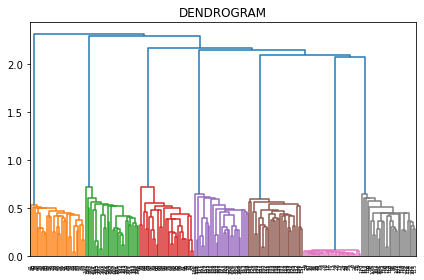

```python
import scipy.cluster.hierarchy as sch
dendrogram = sch.dendrogram(sch.linkage(dataset_1.iloc[:,0:3], method = 'single'))
plt.title('DENDROGRAM')
plt.figure(figsize=(14,11))
plt.show()
```

```python
dataset_1_agglo=AgglomerativeClustering(n_clusters=7,affinity='euclidean', linkage='ward')
dataset_1_agglo.fit(dataset_1.iloc[:,0:3])
dataset_1_agglo.labels_
```

```
array([6, 6, 6, 6, 6, 6, 6, 6, 6, 6, 6, 6, 6, 6, 6, 6, 6, 6, 6, 6, 6, 6,
       6, 6, 6, 6, 6, 6, 6, 6, 6, 6, 4, 4, 4, 4, 4, 4, 4, 4, 4, 4, 4, 4,
       4, 4, 4, 4, 4, 4, 4, 4, 4, 4, 4, 4, 4, 4, 4, 4, 4, 4, 2, 2, 2, 2,
       2, 2, 2, 2, 2, 2, 2, 2, 2, 2, 2, 2, 2, 2, 2, 2, 2, 2, 2, 2, 2, 2,
       2, 2, 2, 2, 5, 5, 5, 5, 5, 5, 5, 5, 5, 5, 5, 5, 5, 5, 5, 5, 5, 5,
       5, 5, 5, 5, 5, 5, 5, 5, 5, 5, 5, 5, 1, 1, 1, 1, 1, 1, 1, 1, 1, 1,
       1, 1, 1, 1, 1, 1, 1, 1, 1, 1, 1, 1, 1, 1, 1, 1, 1, 1, 1, 1, 0, 0,
       0, 0, 0, 0, 0, 0, 0, 0, 0, 0, 0, 0, 0, 0, 0, 0, 0, 0, 0, 0, 0, 0,
       0, 0, 0, 0, 0, 0, 3, 3, 3, 3, 3, 3, 3, 3, 3, 3, 3, 3, 3, 3, 3, 3,
       3, 3, 3, 3, 3, 3, 3, 3, 3, 3, 3, 3, 3, 3])
```

```python
dataset_1_agglo.labels_.sort()
```

```python
dataset_1['Predictedclass']=dataset_1_agglo.labels_+1
```

Generating the contingency of dataset1

```python
matrix_con=sklearn.metrics.cluster.contingency_matrix(dataset_1.iloc[:,3], dataset_1['Predictedclass'])
matrix_con
```

```
array([[30,  2,  0,  0,  0,  0,  0],
       [ 0, 28,  2,  0,  0,  0,  0],
       [ 0,  0, 28,  2,  0,  0,  0],
       [ 0,  0,  0, 28,  2,  0,  0],
       [ 0,  0,  0,  0, 28,  2,  0],
       [ 0,  0,  0,  0,  0, 28,  2],
       [ 0,  0,  0,  0,  0,  0, 30]])
```

Determing the accuracy score of dataset1

Accuracy= number of correct predictions/ Total number of predictions

```python
sklearn.metrics.accuracy_score(dataset_1.iloc[:,3], dataset_1['Predictedclass'])
```

```
0.9433962264150944
```

Determining the F1 score of dataset1

F1 score= 2 x precision x recall/ precision + recall

```python
sklearn.metrics.f1_score(dataset_1.iloc[:,3], dataset_1['Predictedclass'], average='micro')
```

```
0.9433962264150944
```

K Means Clustering of Dataset2

```python
dataset_2=pd.read_csv('Data2.csv')
dataset_2
```

|  | Unnamed: 0 | X | Y | C | Class |
| --- | --- | --- | --- | --- | --- |
| 0 | X1 | 3.277701 | 0.814082 | 0.326574 | 1 |
| 1 | X2 | 0.387577 | 0.176780 | 0.888046 | 1 |
| 2 | X3 | 0.268546 | 0.582963 | 0.080981 | 1 |
| 3 | X4 | 2.031145 | 0.244597 | 0.643921 | 1 |
| 4 | X5 | 0.188677 | 0.461280 | 0.496633 | 1 |
| ... | ... | ... | ... | ... | ... |
| 399 | X400 | 3.248655 | 2.297291 | 3.388138 | 3 |
| 400 | X | 4.100000 | 5.100000 | 0.504558 | 4 |
| 401 | X.1 | 3.900000 | 4.900000 | 0.941634 | 4 |
| 402 | X.2 | 4.000000 | 5.000000 | 0.702123 | 4 |
| 403 | X.3 | 4.100000 | 5.100000 | 0.887645 | 4 |

404 rows × 5 columns

Dropping the column

```python
dataset_2.drop(['Unnamed: 0'], axis=1, inplace=True)
```

Using the head function to get top 5 data

```python
dataset_2.head()
```

|  | X | Y | C | Class |
| --- | --- | --- | --- | --- |
| 0 | 3.277701 | 0.814082 | 0.326574 | 1 |
| 1 | 0.387577 | 0.176780 | 0.888046 | 1 |
| 2 | 0.268546 | 0.582963 | 0.080981 | 1 |
| 3 | 2.031145 | 0.244597 | 0.643921 | 1 |
| 4 | 0.188677 | 0.461280 | 0.496633 | 1 |

Using for loop to determine the range for the cluster.

Using KMeans from sklearn to perfrom KMeans clustering. The n_cluster parameter is in built in Kmeans to specify the number of clusters. Fitting refers to adjusting the parameters in the model to improve accuracy. The process involves running an algorithm on data for which the target variable (“labeled” data) is known to produce a machine learning model. Then, the model’s outcomes are compared to the real, observed values of the target variable to determine the accuracy.

```python
wcss2 = []
for i in range(1, 11):
    kmeans = KMeans(n_clusters = i)
    kmeans.fit(dataset_2.iloc[:,0:3])
    wcss2.append(kmeans.inertia_)
```

Inputing the number of clusters as 4, then fitting the model

```python
k2 = KMeans(n_clusters=4)
X1 = k2.fit_predict(dataset_2.iloc[:,0:3])
```

```python
dataset_2['pclass']=k2.labels_
```

```python
k2.labels_
```

```
array([2, 1, 1, 2, 1, 2, 2, 2, 2, 1, 1, 2, 2, 1, 1, 2, 1, 1, 1, 1, 1, 2,
       1, 1, 1, 1, 2, 2, 2, 2, 2, 2, 1, 2, 2, 2, 1, 1, 2, 1, 2, 1, 1, 2,
       1, 1, 1, 2, 2, 2, 1, 2, 2, 1, 1, 2, 1, 2, 1, 1, 2, 1, 2, 1, 2, 1,
       1, 1, 1, 1, 1, 1, 1, 2, 1, 2, 2, 1, 1, 1, 2, 1, 1, 1, 2, 2, 2, 1,
       2, 1, 1, 2, 1, 1, 1, 2, 1, 1, 2, 2, 2, 2, 1, 2, 1, 2, 1, 1, 2, 2,
       1, 1, 1, 2, 1, 1, 1, 2, 1, 1, 2, 1, 1, 1, 2, 1, 1, 1, 1, 1, 1, 2,
       1, 1, 1, 1, 1, 2, 2, 2, 2, 1, 1, 2, 2, 1, 1, 2, 2, 1, 2, 2, 1, 1,
       1, 1, 1, 2, 1, 1, 1, 1, 1, 2, 2, 1, 2, 2, 2, 1, 1, 2, 1, 1, 2, 1,
       1, 2, 2, 1, 2, 2, 1, 2, 1, 2, 1, 1, 1, 1, 2, 2, 1, 1, 1, 2, 1, 1,
       2, 1, 3, 3, 3, 3, 1, 3, 1, 3, 3, 3, 3, 1, 3, 3, 3, 3, 3, 1, 3, 3,
       1, 3, 3, 3, 3, 3, 3, 3, 1, 3, 3, 1, 3, 3, 3, 3, 3, 3, 3, 3, 3, 1,
       3, 3, 3, 3, 3, 3, 3, 3, 1, 3, 3, 3, 3, 3, 3, 3, 1, 3, 1, 1, 3, 3,
       3, 1, 1, 1, 3, 1, 3, 3, 1, 3, 3, 3, 3, 1, 3, 3, 3, 1, 1, 3, 3, 3,
       1, 3, 3, 3, 3, 3, 3, 1, 3, 3, 3, 1, 1, 3, 0, 0, 0, 0, 0, 0, 0, 0,
       0, 0, 0, 0, 0, 0, 0, 0, 0, 0, 0, 0, 0, 0, 0, 0, 0, 0, 0, 0, 0, 0,
       0, 0, 0, 0, 0, 0, 0, 0, 0, 0, 0, 0, 0, 0, 0, 0, 0, 0, 0, 0, 0, 0,
       0, 0, 0, 0, 0, 0, 0, 0, 0, 0, 0, 0, 0, 0, 0, 0, 0, 0, 0, 0, 0, 0,
       0, 0, 0, 0, 0, 0, 0, 0, 0, 0, 0, 0, 0, 0, 0, 0, 0, 0, 0, 0, 0, 0,
       0, 0, 0, 0, 3, 3, 3, 3], dtype=int32)
```

determing the contingency matrix of dataset2

A Contingency Table is used to display the frequency distribution of class labels among a clustering.

Contingency tables classify outcomes for one variable in rows and the other in columns.

importing Contingency Matrix from sklearn library

```python
c_matrix=sklearn.metrics.cluster.contingency_matrix(dataset_2.iloc[:,3], dataset_2['pclass'])
c_matrix
```

```
array([[  0, 117,  83,   0],
       [  0,  24,   0,  76],
       [100,   0,   0,   0],
       [  0,   0,   0,   4]])
```

```python
k2.labels_.sort()
```

```python
k2.labels_
```

```
array([0, 0, 0, 0, 0, 0, 0, 0, 0, 0, 0, 0, 0, 0, 0, 0, 0, 0, 0, 0, 0, 0,
       0, 0, 0, 0, 0, 0, 0, 0, 0, 0, 0, 0, 0, 0, 0, 0, 0, 0, 0, 0, 0, 0,
       0, 0, 0, 0, 0, 0, 0, 0, 0, 0, 0, 0, 0, 0, 0, 0, 0, 0, 0, 0, 0, 0,
       0, 0, 0, 0, 0, 0, 0, 0, 0, 0, 0, 0, 0, 0, 0, 0, 0, 0, 0, 0, 0, 0,
       0, 0, 0, 0, 0, 0, 0, 0, 0, 0, 0, 0, 1, 1, 1, 1, 1, 1, 1, 1, 1, 1,
       1, 1, 1, 1, 1, 1, 1, 1, 1, 1, 1, 1, 1, 1, 1, 1, 1, 1, 1, 1, 1, 1,
       1, 1, 1, 1, 1, 1, 1, 1, 1, 1, 1, 1, 1, 1, 1, 1, 1, 1, 1, 1, 1, 1,
       1, 1, 1, 1, 1, 1, 1, 1, 1, 1, 1, 1, 1, 1, 1, 1, 1, 1, 1, 1, 1, 1,
       1, 1, 1, 1, 1, 1, 1, 1, 1, 1, 1, 1, 1, 1, 1, 1, 1, 1, 1, 1, 1, 1,
       1, 1, 1, 1, 1, 1, 1, 1, 1, 1, 1, 1, 1, 1, 1, 1, 1, 1, 1, 1, 1, 1,
       1, 1, 1, 1, 1, 1, 1, 1, 1, 1, 1, 1, 1, 1, 1, 1, 1, 1, 1, 1, 1, 2,
       2, 2, 2, 2, 2, 2, 2, 2, 2, 2, 2, 2, 2, 2, 2, 2, 2, 2, 2, 2, 2, 2,
       2, 2, 2, 2, 2, 2, 2, 2, 2, 2, 2, 2, 2, 2, 2, 2, 2, 2, 2, 2, 2, 2,
       2, 2, 2, 2, 2, 2, 2, 2, 2, 2, 2, 2, 2, 2, 2, 2, 2, 2, 2, 2, 2, 2,
       2, 2, 2, 2, 2, 2, 2, 2, 2, 2, 2, 2, 2, 2, 2, 2, 3, 3, 3, 3, 3, 3,
       3, 3, 3, 3, 3, 3, 3, 3, 3, 3, 3, 3, 3, 3, 3, 3, 3, 3, 3, 3, 3, 3,
       3, 3, 3, 3, 3, 3, 3, 3, 3, 3, 3, 3, 3, 3, 3, 3, 3, 3, 3, 3, 3, 3,
       3, 3, 3, 3, 3, 3, 3, 3, 3, 3, 3, 3, 3, 3, 3, 3, 3, 3, 3, 3, 3, 3,
       3, 3, 3, 3, 3, 3, 3, 3], dtype=int32)
```

```python
dataset_2['pclass']=k2.labels_+1
```

Determing the accuracy score of dataset2

Accuracy= number of correct predictions/ Total number of predictions

```python
sklearn.metrics.accuracy_score(dataset_2.iloc[:,3], dataset_2['pclass'])
```

```
0.4183168316831683
```

Determing the F1 score of dataset2

F1 score= 2 x precision x recall/ precision + recall

```python
sklearn.metrics.f1_score(dataset_2.iloc[:,3], dataset_2['pclass'], average='micro')
```

```
0.4183168316831683
```

Plotting 3D graph using 3D scatter plot of dataset2 according to original class

```python
from matplotlib import projections
import pandas as pd

import matplotlib.pyplot as plt
import seaborn as sns
import plotly.express as px

fig=px.scatter_3d(dataset_2,x='X',y='Y',z='C', labels='Class', color='Class')
fig.show()
```

[interactive chart not shown]

Plotting 3D graph using 3D scatter plot of dataset2 according to the class allocated by the clustering algorithm

```python
fig=px.scatter_3d(dataset_2,x='X',y='Y',z='C', labels='pclass', color='pclass')
fig.show()
```

[interactive chart not shown]

Hierarchical Clustering of dataset2

Using scipy library for performing hierarchial clustering.

We have used single linkage here. Single linkage clustering often yields clusters in which individuals are added sequentially to a single group.

The distance between the two clusters is defined as the distance between their two nearest data points.

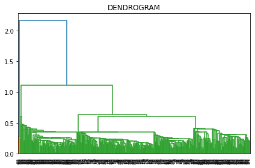

```python
import scipy.cluster.hierarchy as sch
dendrogram = sch.dendrogram(sch.linkage(dataset_2.iloc[:,0:3], method = 'single'))
plt.title('DENDROGRAM')
plt.figure(figsize=(14,20))
plt.show()
```

Using Agglomerative clustering

```python
a_agglo=AgglomerativeClustering(n_clusters=4)
a_agglo.fit(dataset_2.iloc[:,0:3])
a_agglo.labels_
```

```
array([3, 1, 1, 1, 1, 3, 1, 3, 3, 1, 1, 3, 3, 1, 1, 3, 1, 1, 1, 1, 1, 3,
       1, 1, 1, 1, 3, 3, 3, 3, 3, 3, 1, 3, 1, 3, 1, 1, 3, 1, 3, 1, 1, 3,
       1, 1, 1, 3, 1, 1, 1, 1, 3, 1, 1, 3, 1, 1, 1, 1, 1, 1, 3, 1, 3, 1,
       1, 1, 1, 1, 1, 1, 1, 3, 1, 3, 3, 1, 1, 1, 1, 1, 1, 1, 3, 3, 3, 1,
       3, 1, 1, 3, 1, 1, 1, 3, 1, 1, 3, 3, 3, 1, 1, 3, 1, 3, 1, 1, 3, 3,
       1, 1, 1, 3, 1, 1, 1, 1, 1, 1, 3, 1, 1, 1, 3, 1, 1, 1, 1, 1, 1, 3,
       1, 1, 1, 1, 1, 3, 3, 3, 3, 1, 1, 3, 1, 1, 1, 3, 3, 1, 1, 3, 1, 1,
       1, 1, 1, 3, 1, 1, 1, 1, 1, 3, 3, 1, 3, 3, 3, 1, 1, 3, 1, 1, 3, 1,
       1, 3, 3, 1, 3, 3, 1, 3, 1, 3, 1, 1, 1, 1, 3, 3, 1, 1, 1, 3, 1, 1,
       1, 1, 0, 0, 0, 0, 0, 0, 0, 0, 0, 0, 0, 0, 0, 0, 0, 0, 0, 0, 0, 0,
       0, 0, 0, 0, 0, 0, 0, 0, 0, 0, 0, 0, 0, 0, 0, 0, 0, 0, 0, 0, 0, 0,
       0, 0, 0, 0, 0, 0, 0, 0, 0, 0, 0, 0, 0, 0, 0, 0, 0, 0, 0, 0, 0, 0,
       0, 0, 0, 0, 0, 0, 0, 0, 0, 0, 0, 0, 0, 0, 0, 0, 0, 0, 0, 0, 0, 0,
       0, 0, 0, 0, 0, 0, 0, 0, 0, 0, 0, 0, 0, 0, 2, 2, 2, 2, 2, 2, 2, 2,
       2, 2, 2, 2, 2, 2, 2, 2, 2, 2, 2, 2, 2, 2, 2, 2, 2, 2, 2, 2, 2, 2,
       2, 2, 2, 2, 2, 2, 2, 2, 2, 2, 2, 2, 2, 2, 2, 2, 2, 2, 2, 2, 2, 2,
       2, 2, 2, 2, 2, 2, 2, 2, 2, 2, 2, 2, 2, 2, 2, 2, 2, 2, 2, 2, 2, 2,
       2, 2, 2, 2, 2, 2, 2, 2, 2, 2, 2, 2, 2, 2, 2, 2, 2, 2, 2, 2, 2, 2,
       2, 2, 2, 2, 0, 0, 0, 0])
```

```python
a_agglo.labels_.sort()
a_agglo.labels_
```

```
array([0, 0, 0, 0, 0, 0, 0, 0, 0, 0, 0, 0, 0, 0, 0, 0, 0, 0, 0, 0, 0, 0,
       0, 0, 0, 0, 0, 0, 0, 0, 0, 0, 0, 0, 0, 0, 0, 0, 0, 0, 0, 0, 0, 0,
       0, 0, 0, 0, 0, 0, 0, 0, 0, 0, 0, 0, 0, 0, 0, 0, 0, 0, 0, 0, 0, 0,
       0, 0, 0, 0, 0, 0, 0, 0, 0, 0, 0, 0, 0, 0, 0, 0, 0, 0, 0, 0, 0, 0,
       0, 0, 0, 0, 0, 0, 0, 0, 0, 0, 0, 0, 0, 0, 0, 0, 1, 1, 1, 1, 1, 1,
       1, 1, 1, 1, 1, 1, 1, 1, 1, 1, 1, 1, 1, 1, 1, 1, 1, 1, 1, 1, 1, 1,
       1, 1, 1, 1, 1, 1, 1, 1, 1, 1, 1, 1, 1, 1, 1, 1, 1, 1, 1, 1, 1, 1,
       1, 1, 1, 1, 1, 1, 1, 1, 1, 1, 1, 1, 1, 1, 1, 1, 1, 1, 1, 1, 1, 1,
       1, 1, 1, 1, 1, 1, 1, 1, 1, 1, 1, 1, 1, 1, 1, 1, 1, 1, 1, 1, 1, 1,
       1, 1, 1, 1, 1, 1, 1, 1, 1, 1, 1, 1, 1, 1, 1, 1, 1, 1, 1, 1, 1, 1,
       1, 1, 1, 1, 1, 1, 1, 1, 1, 1, 1, 1, 1, 1, 1, 2, 2, 2, 2, 2, 2, 2,
       2, 2, 2, 2, 2, 2, 2, 2, 2, 2, 2, 2, 2, 2, 2, 2, 2, 2, 2, 2, 2, 2,
       2, 2, 2, 2, 2, 2, 2, 2, 2, 2, 2, 2, 2, 2, 2, 2, 2, 2, 2, 2, 2, 2,
       2, 2, 2, 2, 2, 2, 2, 2, 2, 2, 2, 2, 2, 2, 2, 2, 2, 2, 2, 2, 2, 2,
       2, 2, 2, 2, 2, 2, 2, 2, 2, 2, 2, 2, 2, 2, 2, 2, 2, 2, 2, 2, 2, 2,
       2, 2, 2, 2, 2, 3, 3, 3, 3, 3, 3, 3, 3, 3, 3, 3, 3, 3, 3, 3, 3, 3,
       3, 3, 3, 3, 3, 3, 3, 3, 3, 3, 3, 3, 3, 3, 3, 3, 3, 3, 3, 3, 3, 3,
       3, 3, 3, 3, 3, 3, 3, 3, 3, 3, 3, 3, 3, 3, 3, 3, 3, 3, 3, 3, 3, 3,
       3, 3, 3, 3, 3, 3, 3, 3])
```

```python
dataset_2['rclass']=a_agglo.labels_+1
```

determing the contingency matrix of dataset2

```python
o_matrix=sklearn.metrics.cluster.contingency_matrix(dataset_2.iloc[:,3], dataset_2['rclass'])
o_matrix
```

```
array([[104,  96,   0,   0],
       [  0,  35,  65,   0],
       [  0,   0,  35,  65],
       [  0,   0,   0,   4]])
```

Determing the accuracy score of dataset2

Accuracy= number of correct predictions/ Total number of predictions

```python
sklearn.metrics.accuracy_score(dataset_2.iloc[:,3], dataset_2['rclass'])
```

```
0.4405940594059406
```

determing the F1 score of dataset2

F1 score= 2 x precision x recall/ precision + recall

```python
sklearn.metrics.f1_score(dataset_2.iloc[:,3], dataset_2['rclass'], average='micro')
```

```
0.4405940594059406
```

K Means Clustering of dataset3

```python
dataset_3=pd.read_csv('Data3.csv')
dataset_3
```

|  | Unnamed: 0 | X1 | X2 | X3 | Class |
| --- | --- | --- | --- | --- | --- |
| 0 | 1 | 1.295428 | 0.050829 | -0.385217 | 1 |
| 1 | 2 | 1.409178 | -0.035191 | -0.251980 | 1 |
| 2 | 3 | 1.096803 | 0.246365 | -0.415011 | 1 |
| 3 | 4 | 1.463328 | 0.265354 | -0.513488 | 1 |
| 4 | 5 | 1.603284 | 0.080577 | -0.470257 | 1 |
| ... | ... | ... | ... | ... | ... |
| 395 | 396 | 0.795695 | 0.209456 | 1.880609 | 4 |
| 396 | 397 | 0.653127 | -0.703156 | 1.549448 | 4 |
| 397 | 398 | -0.726249 | -0.103244 | 0.694300 | 4 |
| 398 | 399 | 0.808596 | -0.492640 | 1.649370 | 4 |
| 399 | 400 | 0.749291 | -0.447840 | 0.863555 | 4 |

400 rows × 5 columns

```python
dataset_3.drop(['Unnamed: 0'], axis=1, inplace=True)
```

```python
dataset_3
```

|  | X1 | X2 | X3 | Class |
| --- | --- | --- | --- | --- |
| 0 | 1.295428 | 0.050829 | -0.385217 | 1 |
| 1 | 1.409178 | -0.035191 | -0.251980 | 1 |
| 2 | 1.096803 | 0.246365 | -0.415011 | 1 |
| 3 | 1.463328 | 0.265354 | -0.513488 | 1 |
| 4 | 1.603284 | 0.080577 | -0.470257 | 1 |
| ... | ... | ... | ... | ... |
| 395 | 0.795695 | 0.209456 | 1.880609 | 4 |
| 396 | 0.653127 | -0.703156 | 1.549448 | 4 |
| 397 | -0.726249 | -0.103244 | 0.694300 | 4 |
| 398 | 0.808596 | -0.492640 | 1.649370 | 4 |
| 399 | 0.749291 | -0.447840 | 0.863555 | 4 |

400 rows × 4 columns

```python
P3=dataset_3.iloc[:,:3].values
P3
```

```
array([[ 1.295428,  0.050829, -0.385217],
       [ 1.409178, -0.035191, -0.25198 ],
       [ 1.096803,  0.246365, -0.415011],
       ...,
       [-0.726249, -0.103244,  0.6943  ],
       [ 0.808596, -0.49264 ,  1.64937 ],
       [ 0.749291, -0.44784 ,  0.863555]])
```

```python
WCSS3 = []
for i in range(1, 11):
    kmeans = KMeans(n_clusters = i)
    kmeans.fit(dataset_3.iloc[:,0:3])
    WCSS3.append(kmeans.inertia_)
```

```python
k3=KMeans(n_clusters=4)
X3=k3.fit_predict(dataset_3.iloc[:,:3])
```

```python
dataset_3['eclass']=k3.labels_
```

```python
k3.labels_
```

```
array([0, 0, 0, 0, 0, 0, 0, 0, 0, 0, 0, 0, 0, 0, 0, 0, 0, 0, 0, 0, 0, 0,
       0, 0, 0, 0, 0, 0, 0, 0, 0, 0, 0, 0, 0, 0, 0, 0, 0, 0, 0, 0, 0, 0,
       0, 0, 0, 0, 0, 0, 0, 0, 0, 0, 0, 0, 0, 0, 0, 0, 0, 0, 0, 0, 0, 0,
       0, 0, 0, 0, 0, 0, 0, 0, 0, 0, 0, 0, 0, 0, 0, 0, 0, 0, 0, 0, 0, 0,
       0, 0, 0, 0, 0, 0, 0, 0, 0, 0, 0, 0, 2, 2, 2, 2, 2, 2, 2, 2, 2, 2,
       2, 2, 2, 2, 2, 2, 2, 2, 2, 2, 2, 2, 2, 2, 2, 2, 2, 2, 2, 2, 2, 2,
       2, 2, 2, 2, 2, 2, 2, 2, 2, 2, 2, 2, 2, 2, 2, 2, 2, 2, 2, 2, 2, 2,
       2, 2, 2, 2, 2, 2, 2, 2, 2, 2, 2, 2, 2, 2, 2, 2, 2, 2, 2, 2, 2, 2,
       2, 2, 2, 2, 2, 2, 2, 2, 2, 2, 2, 2, 2, 2, 2, 2, 2, 2, 2, 2, 2, 2,
       2, 2, 3, 3, 3, 3, 3, 3, 3, 3, 3, 3, 3, 3, 3, 3, 3, 3, 3, 3, 3, 3,
       3, 3, 3, 3, 3, 3, 3, 3, 3, 3, 3, 3, 3, 3, 3, 3, 3, 3, 3, 3, 3, 3,
       3, 3, 3, 3, 3, 3, 3, 3, 3, 3, 3, 3, 3, 3, 3, 3, 3, 3, 3, 3, 3, 3,
       3, 3, 3, 3, 3, 3, 3, 3, 3, 3, 3, 3, 3, 3, 3, 3, 3, 3, 3, 3, 3, 3,
       3, 3, 3, 3, 3, 3, 3, 3, 3, 3, 3, 3, 3, 3, 1, 1, 1, 1, 1, 1, 1, 1,
       1, 1, 1, 1, 1, 1, 1, 1, 1, 1, 1, 1, 1, 1, 1, 1, 1, 1, 1, 1, 1, 1,
       1, 1, 1, 1, 1, 1, 1, 1, 1, 1, 1, 1, 1, 1, 1, 1, 1, 1, 1, 1, 1, 1,
       1, 1, 1, 1, 1, 1, 1, 1, 1, 1, 1, 1, 1, 1, 1, 1, 1, 1, 1, 1, 1, 1,
       1, 1, 1, 1, 1, 1, 1, 1, 1, 1, 1, 1, 1, 1, 1, 1, 1, 1, 1, 1, 1, 1,
       1, 1, 1, 1], dtype=int32)
```

```python
k3.labels_.sort()
k3.labels_
```

```
array([0, 0, 0, 0, 0, 0, 0, 0, 0, 0, 0, 0, 0, 0, 0, 0, 0, 0, 0, 0, 0, 0,
       0, 0, 0, 0, 0, 0, 0, 0, 0, 0, 0, 0, 0, 0, 0, 0, 0, 0, 0, 0, 0, 0,
       0, 0, 0, 0, 0, 0, 0, 0, 0, 0, 0, 0, 0, 0, 0, 0, 0, 0, 0, 0, 0, 0,
       0, 0, 0, 0, 0, 0, 0, 0, 0, 0, 0, 0, 0, 0, 0, 0, 0, 0, 0, 0, 0, 0,
       0, 0, 0, 0, 0, 0, 0, 0, 0, 0, 0, 0, 1, 1, 1, 1, 1, 1, 1, 1, 1, 1,
       1, 1, 1, 1, 1, 1, 1, 1, 1, 1, 1, 1, 1, 1, 1, 1, 1, 1, 1, 1, 1, 1,
       1, 1, 1, 1, 1, 1, 1, 1, 1, 1, 1, 1, 1, 1, 1, 1, 1, 1, 1, 1, 1, 1,
       1, 1, 1, 1, 1, 1, 1, 1, 1, 1, 1, 1, 1, 1, 1, 1, 1, 1, 1, 1, 1, 1,
       1, 1, 1, 1, 1, 1, 1, 1, 1, 1, 1, 1, 1, 1, 1, 1, 1, 1, 1, 1, 1, 1,
       1, 1, 2, 2, 2, 2, 2, 2, 2, 2, 2, 2, 2, 2, 2, 2, 2, 2, 2, 2, 2, 2,
       2, 2, 2, 2, 2, 2, 2, 2, 2, 2, 2, 2, 2, 2, 2, 2, 2, 2, 2, 2, 2, 2,
       2, 2, 2, 2, 2, 2, 2, 2, 2, 2, 2, 2, 2, 2, 2, 2, 2, 2, 2, 2, 2, 2,
       2, 2, 2, 2, 2, 2, 2, 2, 2, 2, 2, 2, 2, 2, 2, 2, 2, 2, 2, 2, 2, 2,
       2, 2, 2, 2, 2, 2, 2, 2, 2, 2, 2, 2, 2, 2, 3, 3, 3, 3, 3, 3, 3, 3,
       3, 3, 3, 3, 3, 3, 3, 3, 3, 3, 3, 3, 3, 3, 3, 3, 3, 3, 3, 3, 3, 3,
       3, 3, 3, 3, 3, 3, 3, 3, 3, 3, 3, 3, 3, 3, 3, 3, 3, 3, 3, 3, 3, 3,
       3, 3, 3, 3, 3, 3, 3, 3, 3, 3, 3, 3, 3, 3, 3, 3, 3, 3, 3, 3, 3, 3,
       3, 3, 3, 3, 3, 3, 3, 3, 3, 3, 3, 3, 3, 3, 3, 3, 3, 3, 3, 3, 3, 3,
       3, 3, 3, 3], dtype=int32)
```

determing the contingency matrix of dataset3

```python
n_matrix=sklearn.metrics.cluster.contingency_matrix(dataset_3.iloc[:,3], dataset_3['eclass'])
n_matrix
```

```
array([[100,   0,   0,   0],
       [  0,   0, 100,   0],
       [  0,   0,   0, 100],
       [  0, 100,   0,   0]])
```

```python
dataset_3['eclass']=k3.labels_+1
```

determing the accuracy score of dataset3

```python
sklearn.metrics.accuracy_score(dataset_3.iloc[:,3], dataset_3['eclass'])
```

```
1.0
```

determing the F1 score of dataset3

```python
sklearn.metrics.f1_score(dataset_3.iloc[:,3], dataset_3['eclass'], average='micro')
```

```
1.0
```

Plotting 3D graph using plotly.express of dataset3

```python
from matplotlib import projections
import pandas as pd

import matplotlib.pyplot as plt
import seaborn as sns
import plotly.express as px

fig=px.scatter_3d(dataset_3,x='X1',y='X2',z='X3', labels='Class', color='Class')
fig.show()
```

[interactive chart not shown]

```python
fig=px.scatter_3d(dataset_3,x='X1',y='X2',z='X3', labels='eclass', color='eclass')
fig.show()
```

[interactive chart not shown]

Hierarchical Clustering of dataset3

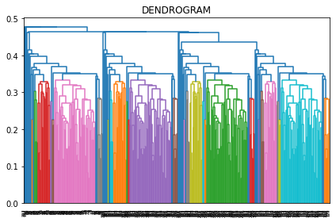

```python
import scipy.cluster.hierarchy as sch
dendrogram = sch.dendrogram(sch.linkage(dataset_3.iloc[:,0:3], method = 'single'))
plt.title('DENDROGRAM')
plt.figure(figsize=(14,11))
plt.show()
```

Using Agglomerative CLustering

```python
b_agglo=AgglomerativeClustering(n_clusters=4)
b_agglo.fit(dataset_3.iloc[:,:3])
b_agglo.labels_
```

```
array([1, 1, 1, 1, 1, 1, 1, 1, 1, 1, 1, 1, 1, 1, 1, 1, 1, 1, 1, 1, 1, 1,
       1, 1, 1, 1, 1, 1, 1, 1, 1, 1, 1, 1, 1, 1, 1, 1, 1, 1, 1, 1, 1, 1,
       1, 1, 1, 1, 1, 1, 1, 1, 1, 1, 1, 1, 1, 1, 1, 1, 1, 1, 1, 1, 1, 1,
       1, 1, 1, 1, 1, 1, 1, 1, 1, 1, 1, 1, 1, 1, 1, 1, 1, 1, 1, 1, 1, 1,
       1, 1, 1, 1, 1, 1, 1, 1, 1, 1, 1, 1, 3, 3, 3, 3, 3, 3, 3, 3, 3, 3,
       3, 3, 3, 3, 3, 3, 3, 3, 3, 3, 3, 3, 3, 3, 3, 3, 3, 3, 3, 3, 3, 3,
       3, 3, 3, 3, 3, 3, 3, 3, 3, 3, 3, 3, 3, 3, 3, 3, 3, 0, 3, 3, 3, 3,
       3, 3, 3, 3, 3, 0, 3, 3, 3, 0, 3, 3, 3, 0, 3, 3, 3, 3, 3, 3, 3, 3,
       3, 3, 3, 3, 3, 3, 3, 3, 3, 3, 3, 3, 3, 3, 3, 3, 3, 3, 0, 3, 3, 3,
       3, 3, 0, 0, 0, 0, 0, 0, 0, 0, 0, 0, 0, 0, 0, 0, 0, 0, 0, 0, 0, 0,
       0, 0, 0, 0, 0, 0, 0, 0, 0, 0, 0, 0, 0, 0, 0, 0, 0, 0, 0, 0, 0, 0,
       0, 0, 0, 0, 0, 0, 0, 0, 0, 0, 0, 0, 0, 0, 0, 0, 0, 0, 0, 0, 0, 0,
       0, 0, 0, 0, 0, 0, 0, 0, 0, 0, 0, 0, 0, 0, 0, 0, 0, 0, 0, 0, 0, 0,
       0, 0, 0, 0, 0, 0, 0, 0, 0, 0, 0, 0, 0, 0, 2, 2, 2, 2, 2, 2, 2, 2,
       2, 2, 2, 2, 2, 2, 2, 2, 2, 2, 2, 2, 2, 2, 2, 2, 2, 2, 2, 2, 2, 2,
       2, 2, 2, 2, 2, 2, 2, 2, 2, 2, 2, 2, 2, 2, 2, 2, 2, 2, 2, 2, 2, 2,
       2, 2, 2, 2, 2, 2, 2, 2, 2, 2, 2, 2, 2, 2, 2, 2, 2, 2, 2, 2, 2, 2,
       2, 2, 2, 2, 2, 2, 2, 2, 2, 2, 2, 2, 2, 2, 2, 2, 2, 2, 2, 2, 2, 2,
       2, 2, 2, 2])
```

```python
b_agglo.labels_.sort()
b_agglo.labels_
```

```
array([0, 0, 0, 0, 0, 0, 0, 0, 0, 0, 0, 0, 0, 0, 0, 0, 0, 0, 0, 0, 0, 0,
       0, 0, 0, 0, 0, 0, 0, 0, 0, 0, 0, 0, 0, 0, 0, 0, 0, 0, 0, 0, 0, 0,
       0, 0, 0, 0, 0, 0, 0, 0, 0, 0, 0, 0, 0, 0, 0, 0, 0, 0, 0, 0, 0, 0,
       0, 0, 0, 0, 0, 0, 0, 0, 0, 0, 0, 0, 0, 0, 0, 0, 0, 0, 0, 0, 0, 0,
       0, 0, 0, 0, 0, 0, 0, 0, 0, 0, 0, 0, 0, 0, 0, 0, 0, 1, 1, 1, 1, 1,
       1, 1, 1, 1, 1, 1, 1, 1, 1, 1, 1, 1, 1, 1, 1, 1, 1, 1, 1, 1, 1, 1,
       1, 1, 1, 1, 1, 1, 1, 1, 1, 1, 1, 1, 1, 1, 1, 1, 1, 1, 1, 1, 1, 1,
       1, 1, 1, 1, 1, 1, 1, 1, 1, 1, 1, 1, 1, 1, 1, 1, 1, 1, 1, 1, 1, 1,
       1, 1, 1, 1, 1, 1, 1, 1, 1, 1, 1, 1, 1, 1, 1, 1, 1, 1, 1, 1, 1, 1,
       1, 1, 1, 1, 1, 1, 1, 2, 2, 2, 2, 2, 2, 2, 2, 2, 2, 2, 2, 2, 2, 2,
       2, 2, 2, 2, 2, 2, 2, 2, 2, 2, 2, 2, 2, 2, 2, 2, 2, 2, 2, 2, 2, 2,
       2, 2, 2, 2, 2, 2, 2, 2, 2, 2, 2, 2, 2, 2, 2, 2, 2, 2, 2, 2, 2, 2,
       2, 2, 2, 2, 2, 2, 2, 2, 2, 2, 2, 2, 2, 2, 2, 2, 2, 2, 2, 2, 2, 2,
       2, 2, 2, 2, 2, 2, 2, 2, 2, 2, 2, 2, 2, 2, 2, 2, 2, 2, 2, 3, 3, 3,
       3, 3, 3, 3, 3, 3, 3, 3, 3, 3, 3, 3, 3, 3, 3, 3, 3, 3, 3, 3, 3, 3,
       3, 3, 3, 3, 3, 3, 3, 3, 3, 3, 3, 3, 3, 3, 3, 3, 3, 3, 3, 3, 3, 3,
       3, 3, 3, 3, 3, 3, 3, 3, 3, 3, 3, 3, 3, 3, 3, 3, 3, 3, 3, 3, 3, 3,
       3, 3, 3, 3, 3, 3, 3, 3, 3, 3, 3, 3, 3, 3, 3, 3, 3, 3, 3, 3, 3, 3,
       3, 3, 3, 3])
```

```python
dataset_3['dclass']=b_agglo.labels_+1
```

determing the contingency matrix of dataset3

```python
t_matrix=sklearn.metrics.cluster.contingency_matrix(dataset_3.iloc[:,3], dataset_3['dclass'])
t_matrix
```

```
array([[100,   0,   0,   0],
       [  5,  95,   0,   0],
       [  0,   5,  95,   0],
       [  0,   0,   5,  95]])
```

determing the accuracy score of dataset3

```python
sklearn.metrics.accuracy_score(dataset_3.iloc[:,3], dataset_3['dclass'])
```

```
0.9625
```

determing the F1 score of dataset3

```python
sklearn.metrics.f1_score(dataset_3.iloc[:,3], dataset_3['dclass'], average='micro')
```

```
0.9625000000000001
```

K Means Clustering of Dataset4

```python
dataset_4=pd.read_csv('Data4.csv')
dataset_4
```

|  | Unnamed: 0 | X1 | X2 | X3 | Class |
| --- | --- | --- | --- | --- | --- |
| 0 | 1 | -0.45300 | -0.8910 | 0.02300 | 1 |
| 1 | 2 | 0.65300 | -0.8460 | 0.02110 | 1 |
| 2 | 3 | 0.39800 | 0.9130 | -0.00139 | 1 |
| 3 | 4 | 0.09520 | 1.0500 | 0.00628 | 1 |
| 4 | 5 | 0.52400 | -0.9410 | 0.03780 | 1 |
| ... | ... | ... | ... | ... | ... |
| 995 | 996 | 0.01520 | 0.0531 | -0.36100 | 2 |
| 996 | 997 | 0.05160 | 0.6910 | 0.87500 | 2 |
| 997 | 998 | -0.00511 | 1.3900 | -0.94700 | 2 |
| 998 | 999 | -0.06710 | 0.7140 | 0.88100 | 2 |
| 999 | 1000 | -0.05770 | 0.4280 | -0.73000 | 2 |

1000 rows × 5 columns

```python
dataset_4.drop(['Unnamed: 0'], axis=1, inplace=True)
```

```python
dataset_4.head()
```

|  | X1 | X2 | X3 | Class |
| --- | --- | --- | --- | --- |
| 0 | -0.4530 | -0.891 | 0.02300 | 1 |
| 1 | 0.6530 | -0.846 | 0.02110 | 1 |
| 2 | 0.3980 | 0.913 | -0.00139 | 1 |
| 3 | 0.0952 | 1.050 | 0.00628 | 1 |
| 4 | 0.5240 | -0.941 | 0.03780 | 1 |

```python
wcss4 = []
for i in range(1, 11):
    kmeans = KMeans(n_clusters = i)
    kmeans.fit(dataset_4.iloc[:,0:3])
    wcss4.append(kmeans.inertia_)
```

```python
k4 = KMeans(n_clusters=2)
X4 = k4.fit_predict(dataset_4.iloc[:,:3])
```

```python
dataset_4['iclass']=k4.labels_
```

```python
k4.labels_
```

```
array([1, 1, 0, 0, 1, 0, 0, 1, 1, 1, 1, 1, 0, 0, 1, 0, 1, 0, 0, 1, 1, 1,
       0, 1, 1, 0, 1, 0, 1, 1, 1, 0, 1, 1, 0, 0, 0, 1, 0, 1, 0, 0, 1, 1,
       0, 0, 1, 1, 0, 1, 1, 1, 1, 1, 1, 1, 1, 1, 0, 1, 1, 0, 0, 0, 1, 1,
       1, 0, 0, 1, 0, 0, 1, 1, 0, 0, 0, 0, 1, 0, 0, 1, 1, 1, 1, 1, 1, 0,
       1, 1, 1, 0, 0, 1, 0, 0, 1, 1, 1, 1, 1, 0, 0, 1, 1, 0, 0, 1, 0, 1,
       0, 1, 1, 1, 0, 0, 1, 1, 1, 0, 0, 1, 1, 1, 0, 1, 1, 1, 1, 0, 1, 1,
       1, 1, 1, 1, 0, 1, 1, 1, 0, 0, 1, 1, 0, 1, 1, 0, 1, 1, 0, 1, 1, 1,
       1, 0, 1, 0, 1, 1, 0, 1, 0, 1, 1, 1, 0, 1, 1, 0, 1, 1, 1, 0, 0, 1,
       1, 1, 1, 1, 1, 1, 1, 1, 0, 1, 1, 1, 1, 1, 1, 1, 0, 1, 0, 1, 1, 1,
       0, 1, 1, 1, 0, 0, 1, 0, 0, 0, 1, 1, 1, 1, 1, 1, 0, 1, 1, 1, 0, 0,
       1, 1, 0, 0, 1, 1, 1, 1, 1, 1, 0, 1, 1, 1, 1, 1, 0, 1, 0, 1, 1, 0,
       1, 0, 1, 1, 0, 0, 0, 1, 1, 0, 1, 0, 0, 1, 0, 1, 1, 0, 1, 1, 1, 1,
       1, 1, 1, 0, 0, 1, 1, 0, 0, 1, 1, 0, 1, 0, 0, 1, 1, 0, 0, 0, 0, 1,
       0, 1, 0, 1, 1, 1, 1, 0, 1, 1, 1, 0, 1, 0, 1, 1, 0, 1, 0, 1, 1, 1,
       1, 1, 0, 1, 1, 1, 0, 0, 1, 1, 1, 0, 1, 1, 1, 1, 0, 0, 0, 0, 1, 1,
```

[output cut: 31 more lines]

```python
k4.labels_.sort()
k4.labels_
```

```
array([0, 0, 0, 0, 0, 0, 0, 0, 0, 0, 0, 0, 0, 0, 0, 0, 0, 0, 0, 0, 0, 0,
       0, 0, 0, 0, 0, 0, 0, 0, 0, 0, 0, 0, 0, 0, 0, 0, 0, 0, 0, 0, 0, 0,
       0, 0, 0, 0, 0, 0, 0, 0, 0, 0, 0, 0, 0, 0, 0, 0, 0, 0, 0, 0, 0, 0,
       0, 0, 0, 0, 0, 0, 0, 0, 0, 0, 0, 0, 0, 0, 0, 0, 0, 0, 0, 0, 0, 0,
       0, 0, 0, 0, 0, 0, 0, 0, 0, 0, 0, 0, 0, 0, 0, 0, 0, 0, 0, 0, 0, 0,
       0, 0, 0, 0, 0, 0, 0, 0, 0, 0, 0, 0, 0, 0, 0, 0, 0, 0, 0, 0, 0, 0,
       0, 0, 0, 0, 0, 0, 0, 0, 0, 0, 0, 0, 0, 0, 0, 0, 0, 0, 0, 0, 0, 0,
       0, 0, 0, 0, 0, 0, 0, 0, 0, 0, 0, 0, 0, 0, 0, 0, 0, 0, 0, 0, 0, 0,
       0, 0, 0, 0, 0, 0, 0, 0, 0, 0, 0, 0, 0, 0, 0, 0, 0, 0, 0, 0, 0, 0,
       0, 0, 0, 0, 0, 0, 0, 0, 0, 0, 0, 0, 0, 0, 0, 0, 0, 0, 0, 0, 0, 0,
       0, 0, 0, 0, 0, 0, 0, 0, 0, 0, 0, 0, 0, 0, 0, 0, 0, 0, 0, 0, 0, 0,
       0, 0, 0, 0, 0, 0, 0, 0, 0, 0, 0, 0, 0, 0, 0, 0, 0, 0, 0, 0, 0, 0,
       0, 0, 0, 0, 0, 0, 0, 0, 0, 0, 0, 0, 0, 0, 0, 0, 0, 0, 0, 0, 0, 0,
       0, 0, 0, 0, 0, 0, 0, 0, 0, 0, 0, 0, 0, 0, 0, 0, 0, 0, 0, 0, 0, 0,
       0, 0, 0, 0, 0, 0, 0, 0, 0, 0, 0, 0, 0, 0, 0, 0, 0, 0, 0, 0, 0, 0,
```

[output cut: 31 more lines]

determining the contingency matrix of dataset4

```python
i_matrix=sklearn.metrics.cluster.contingency_matrix(dataset_4.iloc[:,3], dataset_4['iclass'])
i_matrix
```

```
array([[173, 327],
       [326, 174]])
```

```python
dataset_4['iclass']=k4.labels_+1
```

determining the accuracy score of dataset4

```python
sklearn.metrics.accuracy_score(dataset_4.iloc[:,3], dataset_4['iclass'])
```

```
0.999
```

determing the F1 score of dataset4

```python
sklearn.metrics.f1_score(dataset_4.iloc[:,3], dataset_4['iclass'],average='micro')
```

```
0.999
```

Plotting 3D graph using plotly.express of dataset4

```python
from matplotlib import projections
import pandas as pd

import matplotlib.pyplot as plt
import seaborn as sns
import plotly.express as px

fig=px.scatter_3d(dataset_4,x='X1',y='X2',z='X3', labels='Class', color='Class')
fig.show()
```

[interactive chart not shown]

```python
fig=px.scatter_3d(dataset_4,x='X1',y='X2',z='X3', labels='iclass', color='iclass')
fig.show()
```

[interactive chart not shown]

Hierarchical Clustering of dataset4

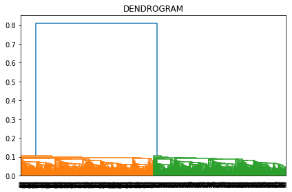

```python
import scipy.cluster.hierarchy as sch
dendrogram = sch.dendrogram(sch.linkage(dataset_4.iloc[:,0:3], method = 'single'))
plt.title('DENDROGRAM')
plt.figure(figsize=(14,20))
plt.show()
```

Using Agglomerative Clustering

```python
c_agglo=AgglomerativeClustering(n_clusters=2)
c_agglo.fit(dataset_4.iloc[:,:3])
c_agglo.labels_
```

```
array([1, 1, 0, 0, 1, 0, 0, 1, 1, 1, 0, 1, 0, 0, 1, 0, 1, 0, 0, 1, 1, 1,
       0, 1, 1, 0, 1, 0, 1, 1, 0, 0, 1, 1, 0, 0, 0, 1, 0, 1, 0, 0, 1, 1,
       0, 0, 1, 1, 0, 1, 1, 1, 1, 1, 1, 1, 1, 1, 0, 1, 1, 0, 0, 0, 1, 1,
       1, 0, 0, 1, 0, 0, 1, 1, 0, 0, 0, 0, 1, 0, 0, 0, 1, 1, 1, 1, 1, 0,
       1, 1, 1, 0, 0, 1, 0, 0, 1, 1, 1, 1, 1, 0, 0, 1, 1, 0, 0, 1, 0, 1,
       0, 0, 1, 1, 0, 0, 1, 1, 1, 0, 0, 0, 1, 0, 0, 1, 1, 1, 1, 0, 1, 1,
       1, 1, 1, 1, 0, 0, 1, 1, 0, 0, 1, 1, 0, 1, 0, 0, 1, 1, 0, 1, 0, 1,
       0, 0, 1, 0, 1, 1, 0, 1, 0, 1, 1, 1, 0, 1, 1, 0, 1, 1, 1, 0, 0, 1,
       1, 1, 1, 1, 1, 1, 1, 1, 0, 1, 1, 0, 1, 1, 1, 1, 0, 1, 0, 1, 1, 1,
       0, 1, 1, 1, 0, 0, 1, 0, 0, 0, 1, 1, 1, 1, 1, 1, 0, 1, 0, 1, 0, 0,
       1, 1, 0, 0, 1, 1, 1, 1, 1, 1, 0, 1, 1, 1, 1, 1, 0, 1, 0, 1, 1, 0,
       1, 0, 1, 1, 0, 0, 0, 1, 1, 0, 0, 0, 0, 1, 0, 1, 1, 0, 0, 1, 1, 1,
       1, 1, 1, 0, 0, 1, 1, 0, 0, 0, 1, 0, 1, 0, 0, 1, 1, 0, 0, 0, 0, 1,
       0, 1, 0, 1, 1, 1, 1, 0, 1, 1, 1, 0, 1, 0, 1, 1, 0, 1, 0, 1, 1, 1,
       1, 1, 0, 1, 1, 1, 0, 0, 1, 1, 1, 0, 1, 1, 1, 0, 0, 0, 0, 0, 1, 1,
```

[output cut: 31 more lines]

```python
c_agglo.labels_.sort()
c_agglo.labels_
```

```
array([0, 0, 0, 0, 0, 0, 0, 0, 0, 0, 0, 0, 0, 0, 0, 0, 0, 0, 0, 0, 0, 0,
       0, 0, 0, 0, 0, 0, 0, 0, 0, 0, 0, 0, 0, 0, 0, 0, 0, 0, 0, 0, 0, 0,
       0, 0, 0, 0, 0, 0, 0, 0, 0, 0, 0, 0, 0, 0, 0, 0, 0, 0, 0, 0, 0, 0,
       0, 0, 0, 0, 0, 0, 0, 0, 0, 0, 0, 0, 0, 0, 0, 0, 0, 0, 0, 0, 0, 0,
       0, 0, 0, 0, 0, 0, 0, 0, 0, 0, 0, 0, 0, 0, 0, 0, 0, 0, 0, 0, 0, 0,
       0, 0, 0, 0, 0, 0, 0, 0, 0, 0, 0, 0, 0, 0, 0, 0, 0, 0, 0, 0, 0, 0,
       0, 0, 0, 0, 0, 0, 0, 0, 0, 0, 0, 0, 0, 0, 0, 0, 0, 0, 0, 0, 0, 0,
       0, 0, 0, 0, 0, 0, 0, 0, 0, 0, 0, 0, 0, 0, 0, 0, 0, 0, 0, 0, 0, 0,
       0, 0, 0, 0, 0, 0, 0, 0, 0, 0, 0, 0, 0, 0, 0, 0, 0, 0, 0, 0, 0, 0,
       0, 0, 0, 0, 0, 0, 0, 0, 0, 0, 0, 0, 0, 0, 0, 0, 0, 0, 0, 0, 0, 0,
       0, 0, 0, 0, 0, 0, 0, 0, 0, 0, 0, 0, 0, 0, 0, 0, 0, 0, 0, 0, 0, 0,
       0, 0, 0, 0, 0, 0, 0, 0, 0, 0, 0, 0, 0, 0, 0, 0, 0, 0, 0, 0, 0, 0,
       0, 0, 0, 0, 0, 0, 0, 0, 0, 0, 0, 0, 0, 0, 0, 0, 0, 0, 0, 0, 0, 0,
       0, 0, 0, 0, 0, 0, 0, 0, 0, 0, 0, 0, 0, 0, 0, 0, 0, 0, 0, 0, 0, 0,
       0, 0, 0, 0, 0, 0, 0, 0, 0, 0, 0, 0, 0, 0, 0, 0, 0, 0, 0, 0, 0, 0,
```

[output cut: 31 more lines]

```python
dataset_4['cclass']=c_agglo.labels_+1
```

determining the contingency matrix of dataset4

```python
g_matrix=sklearn.metrics.cluster.contingency_matrix(dataset_4.iloc[:,3], dataset_4['cclass'])
g_matrix
```

```
array([[500,   0],
       [201, 299]])
```

determining the accuracy score of dataset4

```python
sklearn.metrics.accuracy_score(dataset_4.iloc[:,3], dataset_4['cclass'])
```

```
0.799
```

determining the F1 score of dataset4

```python
sklearn.metrics.f1_score(dataset_4.iloc[:,3], dataset_4['cclass'], average='micro')
```

```
0.799
```

K Means clustering of dataset5

```python
dataset_5=pd.read_csv('Data5.csv')
dataset_5
```

|  | Unnamed: 0 | X1 | X2 | X3 | Class |
| --- | --- | --- | --- | --- | --- |
| 0 | 1 | -4.822490 | -50.402170 | 4.020861 | 1 |
| 1 | 2 | -44.460120 | 20.964670 | -11.492060 | 1 |
| 2 | 3 | 50.001020 | 0.780748 | 9.134460 | 1 |
| 3 | 4 | -41.699080 | -22.310060 | 16.314120 | 1 |
| 4 | 5 | 4.425242 | -4.666664 | 50.223740 | 1 |
| ... | ... | ... | ... | ... | ... |
| 795 | 796 | -1.531027 | 0.681636 | 0.543271 | 2 |
| 796 | 797 | 0.500754 | -1.848209 | 0.605654 | 2 |
| 797 | 798 | 1.089574 | -0.246493 | -3.355758 | 2 |
| 798 | 799 | -1.907717 | 4.964502 | 2.098423 | 2 |
| 799 | 800 | 3.415463 | 4.529521 | -1.617736 | 2 |

800 rows × 5 columns

```python
dataset_5.drop(['Unnamed: 0'], axis=1, inplace=True)
```

```python
dataset_5.head()
```

|  | X1 | X2 | X3 | Class |
| --- | --- | --- | --- | --- |
| 0 | -4.822490 | -50.402170 | 4.020861 | 1 |
| 1 | -44.460120 | 20.964670 | -11.492060 | 1 |
| 2 | 50.001020 | 0.780748 | 9.134460 | 1 |
| 3 | -41.699080 | -22.310060 | 16.314120 | 1 |
| 4 | 4.425242 | -4.666664 | 50.223740 | 1 |

```python
wcss5 = []
for i in range(1, 11):
    kmeans = KMeans(n_clusters = i)
    kmeans.fit(dataset_5.iloc[:,0:3])
    wcss5.append(kmeans.inertia_)
```

```python
k5=KMeans(n_clusters=2)
X5=k5.fit_predict(dataset_5.iloc[:,:3])
```

```python
dataset_5['tclass']=k5.labels_
```

```python
k5.labels_
```

```
array([1, 1, 1, 0, 0, 0, 0, 1, 1, 0, 0, 0, 1, 0, 0, 1, 1, 0, 0, 1, 1, 0,
       0, 1, 0, 1, 0, 0, 0, 1, 1, 1, 0, 0, 0, 0, 1, 0, 0, 0, 0, 0, 1, 1,
       1, 1, 0, 1, 0, 1, 1, 1, 1, 1, 0, 1, 1, 1, 0, 1, 0, 0, 1, 1, 1, 1,
       0, 1, 1, 1, 1, 0, 1, 0, 1, 1, 0, 1, 0, 1, 0, 1, 1, 1, 1, 0, 0, 1,
       1, 0, 1, 0, 0, 1, 1, 1, 1, 1, 0, 0, 0, 0, 1, 0, 1, 0, 0, 1, 0, 1,
       1, 0, 1, 0, 1, 1, 0, 0, 1, 0, 1, 1, 1, 1, 1, 1, 0, 0, 0, 0, 1, 0,
       0, 0, 1, 0, 0, 1, 0, 0, 1, 1, 1, 1, 1, 1, 1, 0, 1, 1, 1, 0, 1, 1,
       1, 0, 1, 1, 1, 1, 1, 1, 0, 1, 1, 0, 0, 0, 1, 1, 0, 0, 1, 1, 1, 0,
       0, 1, 0, 1, 1, 1, 1, 0, 0, 0, 0, 0, 0, 1, 1, 0, 0, 1, 1, 0, 1, 0,
       1, 1, 1, 1, 0, 1, 1, 1, 1, 1, 1, 0, 1, 1, 0, 0, 1, 1, 1, 1, 0, 1,
       1, 0, 1, 1, 0, 1, 1, 1, 1, 0, 0, 0, 0, 0, 0, 1, 1, 1, 0, 1, 1, 1,
       0, 1, 1, 1, 0, 1, 0, 0, 0, 0, 1, 1, 1, 1, 0, 1, 1, 0, 1, 1, 1, 1,
       1, 1, 1, 0, 1, 0, 0, 1, 0, 0, 0, 1, 1, 1, 0, 1, 1, 1, 1, 1, 1, 0,
       0, 0, 0, 0, 1, 0, 1, 1, 1, 0, 0, 1, 1, 0, 0, 1, 1, 1, 1, 1, 1, 0,
       1, 0, 0, 1, 0, 0, 0, 0, 0, 0, 1, 0, 1, 0, 1, 1, 1, 1, 0, 0, 0, 0,
```

[output cut: 22 more lines]

```python
k5.labels_.sort()
k5.labels_
```

```
array([0, 0, 0, 0, 0, 0, 0, 0, 0, 0, 0, 0, 0, 0, 0, 0, 0, 0, 0, 0, 0, 0,
       0, 0, 0, 0, 0, 0, 0, 0, 0, 0, 0, 0, 0, 0, 0, 0, 0, 0, 0, 0, 0, 0,
       0, 0, 0, 0, 0, 0, 0, 0, 0, 0, 0, 0, 0, 0, 0, 0, 0, 0, 0, 0, 0, 0,
       0, 0, 0, 0, 0, 0, 0, 0, 0, 0, 0, 0, 0, 0, 0, 0, 0, 0, 0, 0, 0, 0,
       0, 0, 0, 0, 0, 0, 0, 0, 0, 0, 0, 0, 0, 0, 0, 0, 0, 0, 0, 0, 0, 0,
       0, 0, 0, 0, 0, 0, 0, 0, 0, 0, 0, 0, 0, 0, 0, 0, 0, 0, 0, 0, 0, 0,
       0, 0, 0, 0, 0, 0, 0, 0, 0, 0, 0, 0, 0, 0, 0, 0, 0, 0, 0, 0, 0, 0,
       0, 0, 0, 0, 0, 0, 0, 0, 0, 0, 0, 0, 0, 0, 0, 0, 0, 1, 1, 1, 1, 1,
       1, 1, 1, 1, 1, 1, 1, 1, 1, 1, 1, 1, 1, 1, 1, 1, 1, 1, 1, 1, 1, 1,
       1, 1, 1, 1, 1, 1, 1, 1, 1, 1, 1, 1, 1, 1, 1, 1, 1, 1, 1, 1, 1, 1,
       1, 1, 1, 1, 1, 1, 1, 1, 1, 1, 1, 1, 1, 1, 1, 1, 1, 1, 1, 1, 1, 1,
       1, 1, 1, 1, 1, 1, 1, 1, 1, 1, 1, 1, 1, 1, 1, 1, 1, 1, 1, 1, 1, 1,
       1, 1, 1, 1, 1, 1, 1, 1, 1, 1, 1, 1, 1, 1, 1, 1, 1, 1, 1, 1, 1, 1,
       1, 1, 1, 1, 1, 1, 1, 1, 1, 1, 1, 1, 1, 1, 1, 1, 1, 1, 1, 1, 1, 1,
       1, 1, 1, 1, 1, 1, 1, 1, 1, 1, 1, 1, 1, 1, 1, 1, 1, 1, 1, 1, 1, 1,
```

[output cut: 22 more lines]

determining the contingency matrix of dataset5

```python
e_matrix=sklearn.metrics.cluster.contingency_matrix(dataset_5.iloc[:,3], dataset_5['tclass'])
e_matrix
```

```
array([[171, 229],
       [  0, 400]])
```

```python
dataset_5['tclass']=k5.labels_+1
```

determining the accuracy score of dataset5

```python
sklearn.metrics.accuracy_score(dataset_5.iloc[:,3], dataset_5['tclass'])
```

```
0.71375
```

determining the F1 score of dataset5

```python
sklearn.metrics.f1_score(dataset_5.iloc[:,3], dataset_5['tclass'], average='micro')
```

```
0.7137500000000001
```

Plotting 3D graph using plotly.express of dataset5

```python
from matplotlib import projections
import pandas as pd

import matplotlib.pyplot as plt
import seaborn as sns
import plotly.express as px

fig=px.scatter_3d(dataset_5,x='X1',y='X2',z='X3', labels='Class', color= 'Class')
fig.show()
```

[interactive chart not shown]

```python
fig=px.scatter_3d(dataset_5,x='X1',y='X2',z='X3', labels='tclass', color= 'tclass')
fig.show()
```

[interactive chart not shown]

Hierarchical Clustering of dataset5

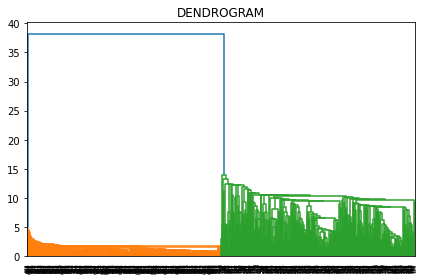

```python
import scipy.cluster.hierarchy as sch
dendrogram = sch.dendrogram(sch.linkage(dataset_5.iloc[:,0:3], method = 'single'))
plt.title('DENDROGRAM')
plt.figure(figsize=(50,40))
plt.show()
```

Using Agglomerative Clustering

```python
d_agglo=AgglomerativeClustering(n_clusters=2)
d_agglo.fit(dataset_5.iloc[:,:3])
d_agglo.labels_
```

```
array([1, 0, 0, 0, 0, 0, 0, 0, 0, 0, 0, 0, 1, 0, 0, 0, 0, 0, 0, 1, 1, 0,
       0, 1, 0, 0, 0, 0, 0, 1, 0, 0, 0, 0, 0, 0, 1, 0, 0, 0, 0, 0, 0, 1,
       1, 0, 0, 1, 0, 0, 1, 1, 0, 1, 0, 1, 1, 1, 0, 0, 0, 0, 0, 1, 1, 0,
       0, 1, 0, 1, 0, 0, 1, 0, 0, 1, 0, 1, 0, 1, 0, 0, 1, 0, 0, 0, 0, 0,
       1, 0, 0, 0, 0, 0, 0, 0, 0, 1, 0, 0, 0, 0, 1, 0, 0, 0, 0, 0, 0, 0,
       0, 0, 1, 0, 1, 1, 0, 0, 0, 0, 0, 0, 0, 0, 0, 0, 0, 0, 0, 0, 0, 0,
       0, 0, 1, 0, 0, 1, 0, 0, 1, 0, 0, 1, 1, 1, 0, 0, 0, 1, 1, 0, 1, 1,
       1, 0, 0, 1, 0, 1, 1, 0, 0, 1, 1, 0, 0, 0, 1, 0, 0, 0, 0, 0, 1, 0,
       0, 1, 0, 1, 0, 0, 1, 0, 0, 0, 0, 0, 0, 1, 0, 0, 0, 0, 0, 0, 1, 0,
       1, 1, 1, 0, 0, 1, 1, 1, 0, 0, 1, 0, 1, 0, 0, 0, 0, 1, 1, 0, 0, 0,
       1, 0, 0, 1, 0, 0, 1, 0, 1, 0, 0, 0, 0, 0, 0, 0, 1, 1, 0, 1, 0, 0,
       0, 1, 0, 1, 0, 1, 0, 0, 0, 0, 0, 1, 0, 0, 0, 0, 0, 0, 1, 1, 1, 1,
       1, 1, 1, 0, 0, 0, 0, 1, 0, 0, 0, 1, 1, 0, 0, 1, 1, 1, 0, 1, 1, 0,
       0, 0, 0, 0, 0, 0, 0, 1, 0, 0, 0, 1, 1, 0, 0, 1, 1, 0, 1, 1, 1, 0,
       1, 0, 0, 1, 0, 0, 0, 0, 0, 0, 1, 0, 1, 0, 0, 0, 0, 1, 0, 0, 0, 0,
```

[output cut: 22 more lines]

```python
d_agglo.labels_.sort()
d_agglo.labels_
```

```
array([0, 0, 0, 0, 0, 0, 0, 0, 0, 0, 0, 0, 0, 0, 0, 0, 0, 0, 0, 0, 0, 0,
       0, 0, 0, 0, 0, 0, 0, 0, 0, 0, 0, 0, 0, 0, 0, 0, 0, 0, 0, 0, 0, 0,
       0, 0, 0, 0, 0, 0, 0, 0, 0, 0, 0, 0, 0, 0, 0, 0, 0, 0, 0, 0, 0, 0,
       0, 0, 0, 0, 0, 0, 0, 0, 0, 0, 0, 0, 0, 0, 0, 0, 0, 0, 0, 0, 0, 0,
       0, 0, 0, 0, 0, 0, 0, 0, 0, 0, 0, 0, 0, 0, 0, 0, 0, 0, 0, 0, 0, 0,
       0, 0, 0, 0, 0, 0, 0, 0, 0, 0, 0, 0, 0, 0, 0, 0, 0, 0, 0, 0, 0, 0,
       0, 0, 0, 0, 0, 0, 0, 0, 0, 0, 0, 0, 0, 0, 0, 0, 0, 0, 0, 0, 0, 0,
       0, 0, 0, 0, 0, 0, 0, 0, 0, 0, 0, 0, 0, 0, 0, 0, 0, 0, 0, 0, 0, 0,
       0, 0, 0, 0, 0, 0, 0, 0, 0, 0, 0, 0, 0, 0, 0, 0, 0, 0, 0, 0, 0, 0,
       0, 0, 0, 0, 0, 0, 0, 0, 0, 0, 0, 0, 0, 0, 0, 0, 0, 0, 0, 0, 0, 0,
       0, 0, 0, 0, 0, 0, 0, 0, 0, 0, 0, 0, 0, 0, 0, 0, 0, 0, 0, 0, 0, 0,
       0, 0, 0, 0, 0, 0, 0, 0, 0, 0, 0, 0, 0, 0, 0, 0, 0, 0, 0, 0, 0, 0,
       0, 0, 0, 0, 0, 0, 0, 0, 0, 0, 0, 0, 0, 0, 0, 0, 0, 0, 0, 0, 0, 0,
       0, 0, 0, 0, 0, 0, 0, 0, 0, 0, 0, 0, 0, 0, 0, 0, 0, 0, 0, 0, 0, 0,
       0, 0, 0, 0, 0, 0, 0, 0, 0, 0, 0, 0, 0, 0, 0, 0, 0, 0, 0, 0, 0, 0,
```

[output cut: 22 more lines]

```python
dataset_5['fclass']=d_agglo.labels_+1
```

determining the contingency matrix of dataset5

```python
y_matrix=sklearn.metrics.cluster.contingency_matrix(dataset_5.iloc[:,3], dataset_5['fclass'])
y_matrix
```

```
array([[400,   0],
       [274, 126]])
```

determining the accuracy score of dataset5

```python
sklearn.metrics.accuracy_score(dataset_5.iloc[:,3], dataset_5['fclass'])
```

```
0.6575
```

determining the f1 score of dataset5

```python
sklearn.metrics.f1_score(dataset_5.iloc[:,3], dataset_5['fclass'], average='micro')
```

```
0.6575
```

K Means clustering of dataset 6

```python
dataset_6=pd.read_csv('Data6.csv')
dataset_6
```

|  | Unnamed: 0 | X1 | X2 | Class |
| --- | --- | --- | --- | --- |
| 0 | 1 | 1.388261 | 2.076096 | 1 |
| 1 | 2 | 2.177247 | 3.102304 | 1 |
| 2 | 3 | 0.378645 | 5.307610 | 1 |
| 3 | 4 | 3.681732 | 1.622681 | 1 |
| 4 | 5 | 2.462861 | 2.777897 | 1 |
| ... | ... | ... | ... | ... |
| 4091 | 4092 | 0.909687 | 0.375763 | 2 |
| 4092 | 4093 | 2.698381 | 0.511262 | 2 |
| 4093 | 4094 | 1.078797 | 1.526153 | 2 |
| 4094 | 4095 | 1.974889 | -0.649343 | 2 |
| 4095 | 4096 | -0.127192 | -0.763974 | 2 |

4096 rows × 4 columns

```python
dataset_6.drop(['Unnamed: 0'], axis=1, inplace=True)
```

```python
dataset_6.head()
```

|  | X1 | X2 | Class |
| --- | --- | --- | --- |
| 0 | 1.388261 | 2.076096 | 1 |
| 1 | 2.177247 | 3.102304 | 1 |
| 2 | 0.378645 | 5.307610 | 1 |
| 3 | 3.681732 | 1.622681 | 1 |
| 4 | 2.462861 | 2.777897 | 1 |

```python
wcss6 = []
for i in range(1, 11):
    kmeans = KMeans(n_clusters = i)
    kmeans.fit(dataset_6.iloc[:,0:3])
    wcss6.append(kmeans.inertia_)
```

```python
k6 = KMeans(n_clusters=2)
X6 = k6.fit_predict(dataset_6.iloc[:,0:3])
```

```python
dataset_6['gclass']=k6.labels_
```

```python
k6.labels_
```

```
array([0, 0, 0, ..., 1, 1, 1], dtype=int32)
```

```python
k6.labels_.sort()
k6.labels_
```

```
array([0, 0, 0, ..., 1, 1, 1], dtype=int32)
```

determining the contingency matrix of dataset6

```python
x_matrix=sklearn.metrics.cluster.contingency_matrix(dataset_6.iloc[:,3], dataset_6['gclass'])
x_matrix
```

```
array([[2138,    0],
       [   0, 1958]])
```

```python
dataset_6['gclass']=k6.labels_+1
```

determining the accuracy score of dataset6

```python
sklearn.metrics.accuracy_score(dataset_6.iloc[:,3], dataset_6['gclass'])
```

```
1.0
```

determining the F1 score of dataset6

```python
sklearn.metrics.f1_score(dataset_6.iloc[:,3], dataset_6['gclass'], average='micro')
```

```
1.0
```

Plotting 2D graph using scatterplot of dataset6

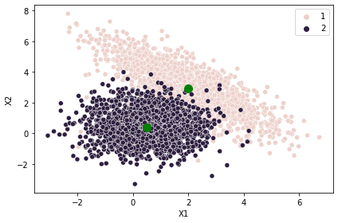

```python
sns.scatterplot(x='X1', y='X2', hue=k6.labels_+1, data=dataset_6)
plt.scatter(k6.cluster_centers_[:,0], k6.cluster_centers_[:,1], s = 100, c = 'green', label = 'Centroids')
plt.show()
plt.rcParams["figure.figsize"] = [8, 8]
plt.rcParams["figure.autolayout"] = True
```

Plotting second 2D graph using scatterplot of dataset6

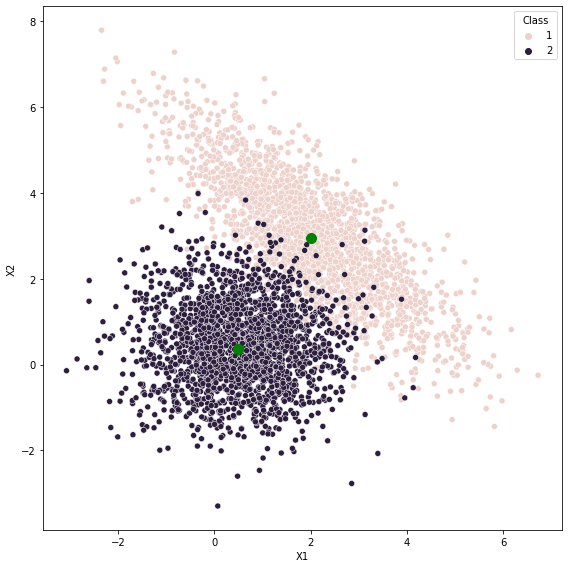

```python
sns.scatterplot(x='X1', y='X2', hue ='Class', data=dataset_6)
plt.scatter(k6.cluster_centers_[:,0], k6.cluster_centers_[:,1], s = 100, c = 'green', label = 'Centroids')
plt.show()
plt.rcParams["figure.figsize"] = [8, 8]
plt.rcParams["figure.autolayout"] = True
```

Hierarchical Clustering of dataset 6

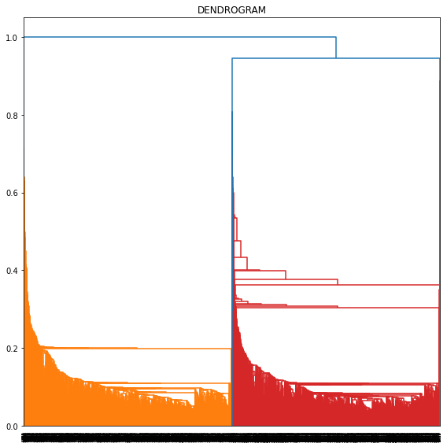

```python
import scipy.cluster.hierarchy as sch
dendrogram = sch.dendrogram(sch.linkage(dataset_6.iloc[:,0:3], method = 'single'))
plt.title('DENDROGRAM')
plt.figure(figsize=(50,40))
plt.show()
```

```python
e_agglo=AgglomerativeClustering(n_clusters=2, affinity='Euclidean', linkage='single')
e_agglo.fit_predict(dataset_6.iloc[:,:3])
e_agglo.labels_
```

```
array([1, 1, 1, ..., 0, 0, 0])
```

```python
e_agglo.labels_.sort()
e_agglo.labels_
```

```
array([0, 0, 0, ..., 1, 1, 1])
```

```python
dataset_6['hclass']=e_agglo.labels_+1
```

determining the contingency matrix of dataset6

```python
w_matrix=sklearn.metrics.cluster.contingency_matrix(dataset_6.iloc[:,2], dataset_6['hclass'])
w_matrix
```

```
array([[2048,    0],
       [   0, 2048]])
```

determining the accuracy score of dataset6

```python
sklearn.metrics.accuracy_score(dataset_6.iloc[:,3], dataset_6['hclass'])
```

```
0.97802734375
```

determining the F1 score of dataset6

```python
sklearn.metrics.f1_score(dataset_6.iloc[:,3], dataset_6['hclass'], average='micro')
```

```
0.97802734375
```

K Means clustering of dataset7

```python
dataset_7=pd.read_csv('Data7.csv')
dataset_7
```

|  | Unnamed: 0 | X1 | X2 | Class |
| --- | --- | --- | --- | --- |
| 0 | 1 | -3.000000 | -3.000000 | 5 |
| 1 | 2 | -3.000000 | 3.000000 | 4 |
| 2 | 3 | 3.000000 | -3.000000 | 6 |
| 3 | 4 | 3.000000 | 3.000000 | 3 |
| 4 | 5 | -0.417091 | 0.114782 | 1 |
| ... | ... | ... | ... | ... |
| 765 | 766 | -1.604434 | -1.118861 | 2 |
| 766 | 767 | -3.050000 | -3.050000 | 5 |
| 767 | 768 | -3.050000 | 2.950000 | 4 |
| 768 | 769 | 2.950000 | -3.050000 | 6 |
| 769 | 770 | 2.950000 | 2.950000 | 3 |

770 rows × 4 columns

```python
dataset_7.drop(['Unnamed: 0'], axis=1, inplace=True)
```

```python
dataset_7.head()
```

|  | X1 | X2 | Class |
| --- | --- | --- | --- |
| 0 | -3.000000 | -3.000000 | 5 |
| 1 | -3.000000 | 3.000000 | 4 |
| 2 | 3.000000 | -3.000000 | 6 |
| 3 | 3.000000 | 3.000000 | 3 |
| 4 | -0.417091 | 0.114782 | 1 |

```python
wcss7 = []
for i in range(1, 11):
    kmeans = KMeans(n_clusters = i)
    kmeans.fit(dataset_7.iloc[:,0:2])
    wcss7.append(kmeans.inertia_)
```

```python
k7=KMeans(n_clusters=6)
X7=k7.fit_predict(dataset_7.iloc[:,:3])
```

```python
dataset_7['vclass']=k7.labels_
```

```python
k7.labels_
```

```
array([3, 1, 5, 4, 0, 0, 0, 0, 0, 0, 0, 0, 0, 0, 0, 0, 0, 0, 0, 0, 0, 0,
       0, 0, 0, 0, 0, 0, 0, 0, 0, 0, 0, 0, 0, 0, 0, 0, 0, 0, 0, 0, 0, 0,
       0, 0, 0, 0, 0, 0, 0, 0, 0, 0, 0, 0, 0, 0, 0, 0, 0, 0, 0, 0, 0, 0,
       0, 0, 0, 0, 0, 0, 0, 0, 0, 0, 0, 0, 0, 0, 0, 0, 0, 0, 0, 0, 0, 0,
       0, 0, 0, 0, 0, 0, 0, 0, 0, 0, 0, 0, 0, 0, 0, 0, 0, 0, 0, 0, 0, 0,
       0, 0, 0, 0, 0, 0, 0, 0, 0, 0, 0, 0, 0, 0, 0, 0, 0, 0, 0, 0, 0, 0,
       0, 0, 0, 0, 0, 0, 0, 0, 0, 0, 0, 0, 0, 0, 0, 0, 0, 0, 0, 0, 0, 0,
       0, 0, 0, 0, 0, 0, 0, 0, 0, 0, 0, 0, 0, 0, 0, 0, 0, 0, 0, 0, 0, 0,
       0, 0, 0, 0, 0, 0, 0, 0, 0, 0, 0, 0, 0, 0, 0, 0, 0, 0, 0, 0, 0, 0,
       0, 0, 0, 0, 0, 0, 0, 0, 0, 0, 0, 0, 0, 0, 0, 0, 0, 0, 0, 0, 0, 0,
       0, 0, 0, 0, 0, 0, 0, 0, 0, 0, 0, 0, 0, 0, 0, 0, 0, 0, 0, 0, 0, 0,
       0, 0, 0, 0, 0, 0, 0, 0, 0, 0, 0, 0, 0, 0, 0, 0, 0, 0, 0, 0, 0, 0,
       0, 0, 0, 0, 0, 0, 0, 0, 0, 0, 0, 0, 0, 0, 0, 0, 0, 0, 0, 0, 0, 0,
       0, 0, 0, 0, 0, 0, 0, 0, 0, 0, 0, 0, 0, 0, 0, 0, 0, 0, 0, 0, 0, 0,
       0, 0, 0, 0, 0, 0, 0, 0, 0, 0, 0, 0, 0, 0, 0, 0, 0, 0, 0, 0, 0, 0,
```

[output cut: 21 more lines]

```python
k7.labels_.sort()
k7.labels_
```

```
array([0, 0, 0, 0, 0, 0, 0, 0, 0, 0, 0, 0, 0, 0, 0, 0, 0, 0, 0, 0, 0, 0,
       0, 0, 0, 0, 0, 0, 0, 0, 0, 0, 0, 0, 0, 0, 0, 0, 0, 0, 0, 0, 0, 0,
       0, 0, 0, 0, 0, 0, 0, 0, 0, 0, 0, 0, 0, 0, 0, 0, 0, 0, 0, 0, 0, 0,
       0, 0, 0, 0, 0, 0, 0, 0, 0, 0, 0, 0, 0, 0, 0, 0, 0, 0, 0, 0, 0, 0,
       0, 0, 0, 0, 0, 0, 0, 0, 0, 0, 0, 0, 0, 0, 0, 0, 0, 0, 0, 0, 0, 0,
       0, 0, 0, 0, 0, 0, 0, 0, 0, 0, 0, 0, 0, 0, 0, 0, 0, 0, 0, 0, 0, 0,
       0, 0, 0, 0, 0, 0, 0, 0, 0, 0, 0, 0, 0, 0, 0, 0, 0, 0, 0, 0, 0, 0,
       0, 0, 0, 0, 0, 0, 0, 0, 0, 0, 0, 0, 0, 0, 0, 0, 0, 0, 0, 0, 0, 0,
       0, 0, 0, 0, 0, 0, 0, 0, 0, 0, 0, 0, 0, 0, 0, 0, 0, 0, 0, 0, 0, 0,
       0, 0, 0, 0, 0, 0, 0, 0, 0, 0, 0, 0, 0, 0, 0, 0, 0, 0, 0, 0, 0, 0,
       0, 0, 0, 0, 0, 0, 0, 0, 0, 0, 0, 0, 0, 0, 0, 0, 0, 0, 0, 0, 0, 0,
       0, 0, 0, 0, 0, 0, 0, 0, 0, 0, 0, 0, 0, 0, 0, 0, 0, 0, 0, 0, 0, 0,
       0, 0, 0, 0, 0, 0, 0, 0, 0, 0, 0, 0, 0, 0, 0, 0, 0, 0, 0, 0, 0, 0,
       0, 0, 0, 0, 0, 0, 0, 0, 0, 0, 0, 0, 0, 0, 0, 0, 0, 0, 0, 0, 0, 0,
       0, 0, 0, 0, 0, 0, 0, 0, 0, 0, 0, 0, 0, 0, 0, 0, 0, 0, 0, 0, 0, 0,
```

[output cut: 21 more lines]

determining the contingency matrix of dataset7

```python
v_matrix=sklearn.metrics.cluster.contingency_matrix(dataset_7.iloc[:,3], dataset_7['vclass'])
v_matrix
```

```
array([[395,   0,   0,   0,   0,   0],
       [  0,  93,   0,   0,   0,   0],
       [  0,   0,  97,   0,   0,   0],
       [  0,   0,   0,  95,   0,   0],
       [  0,   0,   0,   0,  87,   0],
       [  0,   0,   0,   0,   0,   3]])
```

```python
dataset_7['vclass']=k7.labels_+1
```

determining the accuracy score of dataset7

```python
sklearn.metrics.accuracy_score(dataset_7.iloc[:,3], dataset_7['vclass'])
```

```
1.0
```

determining the F1 score of dataset7

```python
sklearn.metrics.f1_score(dataset_7.iloc[:,3], dataset_7['vclass'], average='micro')
```

```
1.0
```

plotting 2D graph using scatterplot of dataset7

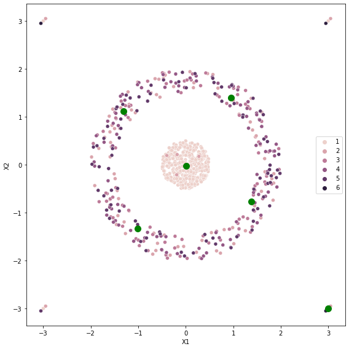

```python
sns.scatterplot(x='X1', y='X2', hue=k7.labels_+1, data=dataset_7)
plt.scatter(k7.cluster_centers_[:,0], k7.cluster_centers_[:,1], s = 100, c = 'green', label = 'Centroids')
plt.show()
plt.rcParams["figure.figsize"] = [8, 8]
plt.rcParams["figure.autolayout"] = True
```

Plotting second 2D graph using scatterplot of dataset7

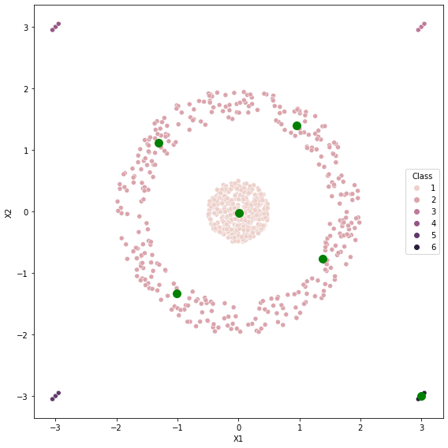

```python
sns.scatterplot(x='X1', y='X2', hue ='Class', data=dataset_7)
plt.scatter(k7.cluster_centers_[:,0], k7.cluster_centers_[:,1], s = 100, c = 'green', label = 'Centroids')
plt.show()
plt.rcParams["figure.figsize"] = [8, 8]
plt.rcParams["figure.autolayout"] = True
```

Hierarchical Clustering of dataset7

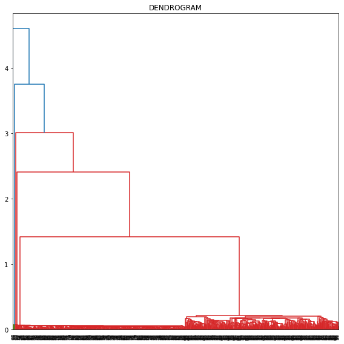

```python
import scipy.cluster.hierarchy as sch
dendrogram = sch.dendrogram(sch.linkage(dataset_7.iloc[:,0:3], method = 'single'))
plt.title('DENDROGRAM')
plt.figure(figsize=(50,40))
plt.show()
```

```python
f_agglo=AgglomerativeClustering(n_clusters=6, affinity='Euclidean', linkage='single')
f_agglo.fit_predict(dataset_7.iloc[:,:2])
f_agglo.labels_
```

```
array([2, 3, 1, 4, 5, 5, 5, 5, 5, 5, 5, 5, 5, 5, 5, 5, 5, 5, 5, 5, 5, 5,
       5, 5, 5, 5, 5, 5, 5, 5, 5, 5, 5, 5, 5, 5, 5, 5, 5, 5, 5, 5, 5, 5,
       5, 5, 5, 5, 5, 5, 5, 5, 5, 5, 5, 5, 5, 5, 5, 5, 5, 5, 5, 5, 5, 5,
       5, 5, 5, 5, 5, 5, 5, 5, 5, 5, 5, 5, 5, 5, 5, 5, 5, 5, 5, 5, 5, 5,
       5, 5, 5, 5, 5, 5, 5, 5, 5, 5, 5, 5, 5, 5, 5, 5, 5, 5, 5, 5, 5, 5,
       5, 5, 5, 5, 5, 5, 5, 5, 5, 5, 5, 5, 5, 5, 5, 5, 5, 5, 5, 5, 5, 5,
       5, 5, 5, 5, 5, 5, 5, 5, 5, 5, 5, 5, 5, 5, 5, 5, 5, 5, 5, 5, 5, 5,
       5, 5, 5, 5, 5, 5, 5, 5, 5, 5, 5, 5, 5, 5, 5, 5, 5, 5, 5, 5, 5, 5,
       5, 5, 5, 5, 5, 5, 5, 5, 5, 5, 5, 5, 5, 5, 5, 5, 5, 5, 5, 5, 5, 5,
       5, 5, 5, 5, 5, 5, 5, 5, 5, 5, 5, 5, 5, 5, 5, 5, 5, 5, 5, 5, 5, 5,
       5, 5, 5, 5, 5, 5, 5, 5, 5, 5, 5, 5, 5, 5, 5, 5, 5, 5, 5, 5, 5, 5,
       5, 5, 5, 5, 5, 5, 5, 5, 5, 5, 5, 5, 5, 5, 5, 5, 5, 5, 5, 5, 5, 5,
       5, 5, 5, 5, 5, 5, 5, 5, 5, 5, 5, 5, 5, 5, 5, 5, 5, 5, 5, 5, 5, 5,
       5, 5, 5, 5, 5, 5, 5, 5, 5, 5, 5, 5, 5, 5, 5, 5, 5, 5, 5, 5, 5, 5,
       5, 5, 5, 5, 5, 5, 5, 5, 5, 5, 5, 5, 5, 5, 5, 5, 5, 5, 5, 5, 5, 5,
```

[output cut: 20 more lines]

```python
f_agglo.labels_.sort()
f_agglo.labels_
```

```
array([0, 0, 0, 0, 0, 0, 0, 0, 0, 0, 0, 0, 0, 0, 0, 0, 0, 0, 0, 0, 0, 0,
       0, 0, 0, 0, 0, 0, 0, 0, 0, 0, 0, 0, 0, 0, 0, 0, 0, 0, 0, 0, 0, 0,
       0, 0, 0, 0, 0, 0, 0, 0, 0, 0, 0, 0, 0, 0, 0, 0, 0, 0, 0, 0, 0, 0,
       0, 0, 0, 0, 0, 0, 0, 0, 0, 0, 0, 0, 0, 0, 0, 0, 0, 0, 0, 0, 0, 0,
       0, 0, 0, 0, 0, 0, 0, 0, 0, 0, 0, 0, 0, 0, 0, 0, 0, 0, 0, 0, 0, 0,
       0, 0, 0, 0, 0, 0, 0, 0, 0, 0, 0, 0, 0, 0, 0, 0, 0, 0, 0, 0, 0, 0,
       0, 0, 0, 0, 0, 0, 0, 0, 0, 0, 0, 0, 0, 0, 0, 0, 0, 0, 0, 0, 0, 0,
       0, 0, 0, 0, 0, 0, 0, 0, 0, 0, 0, 0, 0, 0, 0, 0, 0, 0, 0, 0, 0, 0,
       0, 0, 0, 0, 0, 0, 0, 0, 0, 0, 0, 0, 0, 0, 0, 0, 0, 0, 0, 0, 0, 0,
       0, 0, 0, 0, 0, 0, 0, 0, 0, 0, 0, 0, 0, 0, 0, 0, 0, 0, 0, 0, 0, 0,
       0, 0, 0, 0, 0, 0, 0, 0, 0, 0, 0, 0, 0, 0, 0, 0, 0, 0, 0, 0, 0, 0,
       0, 0, 0, 0, 0, 0, 0, 0, 0, 0, 0, 0, 0, 0, 0, 0, 0, 0, 0, 0, 0, 0,
       0, 0, 0, 0, 0, 0, 0, 0, 0, 0, 0, 0, 0, 0, 0, 0, 0, 0, 0, 0, 0, 0,
       0, 0, 0, 0, 0, 0, 0, 0, 0, 0, 0, 0, 0, 0, 0, 0, 0, 0, 0, 0, 0, 0,
       0, 0, 0, 0, 0, 0, 0, 0, 0, 0, 0, 0, 0, 0, 0, 0, 0, 0, 0, 0, 0, 0,
```

[output cut: 20 more lines]

```python
dataset_7['bclass']=f_agglo.labels_+1
```

determining the contingency matrix of dataset7

```python
m_matrix=sklearn.metrics.cluster.contingency_matrix(dataset_7.iloc[:,2], dataset_7['bclass'])
m_matrix
```

```
array([[359,   3,   3,   3,   3,  24],
       [  0,   0,   0,   0,   0, 363],
       [  1,   0,   0,   0,   0,   2],
       [  1,   0,   0,   0,   0,   2],
       [  1,   0,   0,   0,   0,   2],
       [  1,   0,   0,   0,   0,   2]])
```

determining the accuracy score of dataset7

```python
sklearn.metrics.accuracy_score(dataset_7.iloc[:,2], dataset_7['bclass'])
```

```
0.4688311688311688
```

determining the F1 score of dataset7

```python
sklearn.metrics.f1_score(dataset_7.iloc[:,2], dataset_7['bclass'], average='micro')
```

```
0.4688311688311688
```

K Means clustering of dataset 8

```python
dataset_8=pd.read_csv('Data8.csv')
dataset_8
```

|  | Unnamed: 0 | X1 | X2 | X3 | Class |
| --- | --- | --- | --- | --- | --- |
| 0 | 1 | 0.000000 | 0.000000 | 1.00000 | 1 |
| 1 | 2 | 0.000000 | 0.052336 | 0.99863 | 1 |
| 2 | 3 | 0.049774 | 0.016173 | 0.99863 | 1 |
| 3 | 4 | 0.030762 | -0.042341 | 0.99863 | 1 |
| 4 | 5 | -0.030762 | -0.042341 | 0.99863 | 1 |
| ... | ... | ... | ... | ... | ... |
| 3997 | 3998 | 0.049774 | -0.016173 | -0.99863 | 1 |
| 3998 | 3999 | 0.000000 | -0.052336 | -0.99863 | 1 |
| 3999 | 4000 | -0.049774 | -0.016173 | -0.99863 | 1 |
| 4000 | 4001 | -0.030762 | 0.042341 | -0.99863 | 1 |
| 4001 | 4002 | 0.000000 | 0.000000 | -1.00000 | 1 |

4002 rows × 5 columns

```python
dataset_8.drop(['Unnamed: 0'], axis=1, inplace=True)
```

```python
dataset_8.head()
```

|  | X1 | X2 | X3 | Class |
| --- | --- | --- | --- | --- |
| 0 | 0.000000 | 0.000000 | 1.00000 | 1 |
| 1 | 0.000000 | 0.052336 | 0.99863 | 1 |
| 2 | 0.049774 | 0.016173 | 0.99863 | 1 |
| 3 | 0.030762 | -0.042341 | 0.99863 | 1 |
| 4 | -0.030762 | -0.042341 | 0.99863 | 1 |

```python
wcss8 = []
for i in range(1, 11):
    kmeans = KMeans(n_clusters = i)
    kmeans.fit(dataset_8.iloc[:,0:3])
    wcss8.append(kmeans.inertia_)
```

```python
k8=KMeans(n_clusters=1)
X8=k8.fit_predict(dataset_8.iloc[:,:3])
```

```python
dataset_8['lclass']=k8.labels_
```

```python
k8.labels_
```

```
array([0, 0, 0, ..., 0, 0, 0], dtype=int32)
```

determining the contingency matrix of dataset8

```python
o_matrix=sklearn.metrics.cluster.contingency_matrix(dataset_8.iloc[:,3], dataset_8['lclass'])
o_matrix
```

```
array([[4002]])
```

```python
dataset_8['lclass']=k8.labels_+1
```

determining the accuracy score of dataset8

```python
sklearn.metrics.accuracy_score(dataset_8.iloc[:,3],dataset_8['lclass'])
```

```
1.0
```

determining the F1 score of dataset8

```python
sklearn.metrics.f1_score(dataset_8.iloc[:,3],dataset_8['lclass'], average='micro')
```

```
1.0
```

Plotting 3D graph using plotly.express of dataset8

```python
from matplotlib import projections
import pandas as pd

import matplotlib.pyplot as plt
import seaborn as sns
import plotly.express as px

fig=px.scatter_3d(dataset_8,x='X1',y='X2',z='X3', labels='Class', color= 'Class')
fig.show()
```

[interactive chart not shown]

```python
fig=px.scatter_3d(dataset_8,x='X1',y='X2',z='X3', labels='lclass', color= 'lclass')
fig.show()
```

[interactive chart not shown]

Hierarchical Clustering of dataset8

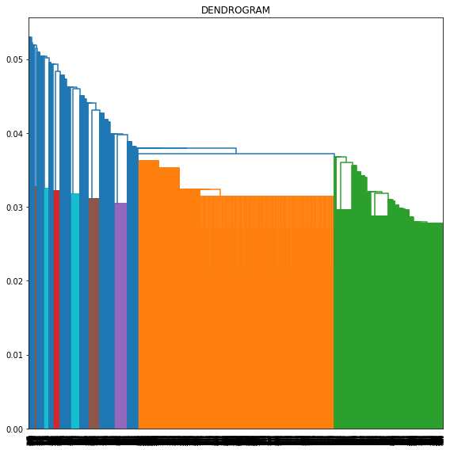

```python
import scipy.cluster.hierarchy as sch
dendrogram = sch.dendrogram(sch.linkage(dataset_8.iloc[:,0:2], method = 'single'))
plt.title('DENDROGRAM')
plt.figure(figsize=(50,40))
plt.show()
```

```python
r_agglo=AgglomerativeClustering(n_clusters=2, affinity='Euclidean', linkage='single')
r_agglo.fit_predict(dataset_8.iloc[:,:3])
r_agglo.labels_
```

```
array([0, 0, 0, ..., 0, 0, 0])
```

```python
dataset_8['kclass']=r_agglo.labels_+1
```

determining the contingency matrix of dataset8

```python
t_matrix=sklearn.metrics.cluster.contingency_matrix(dataset_8.iloc[:,3], dataset_8['kclass'])
t_matrix
```

```
array([[4001,    1]])
```

determining the accuracy score of dataset8

```python
sklearn.metrics.accuracy_score(dataset_8.iloc[:,3], dataset_8['kclass'])
```

```
0.9997501249375312
```

determining the f1 score of dataset8

```python
sklearn.metrics.f1_score(dataset_8.iloc[:,3], dataset_8['kclass'], average='micro')
```

```
0.9997501249375312
```

**TASK 2**

```python
from google.colab import files
uploaded=files.upload()
```

Upload widget is only available when the cell has been executed in the current browser session. Please rerun this cell to enable.

```
Saving World Indicators.csv to World Indicators (1).csv
```

```python
df_world=pd.read_csv('World Indicators.csv')
df_world
```

|  | Birth Rate | Business Tax Rate | Days to Start Business | Energy Usage | GDP | Health Exp % GDP | Health Exp/Capita | Hours to do Tax | Infant Mortality Rate | Internet Usage | Lending Interest | Life Expectancy Female | Life Expectancy Male | Mobile Phone Usage | Population 0-14 | Population 15-64 | Population 65+ | Population Urban | Region | Country |
| --- | --- | --- | --- | --- | --- | --- | --- | --- | --- | --- | --- | --- | --- | --- | --- | --- | --- | --- | --- | --- |
| 0 | 0.025 | 72.0% | 25.0 | 41852.0 | $199,070,864,638 | 0.044 | $233 | 451.0 | 0.023 | 0.1 | 0.080 | 72.0 | 69.0 | 0.9 | 0.272 | 0.681 | 0.047 | 0.682 | Africa | Algeria |
| 1 | 0.046 | 52.1% | 66.0 | 13576.0 | $104,115,863,405 | 0.034 | $178 | 282.0 | 0.107 | 0.1 | 0.188 | 53.0 | 50.0 | 0.5 | 0.477 | 0.499 | 0.024 | 0.409 | Africa | Angola |
| 2 | 0.037 | 65.9% | 29.0 | 3761.0 | $7,294,900,431 | 0.045 | $34 | 270.0 | 0.060 | 0.0 | NaN | 60.0 | 58.0 | 0.8 | 0.432 | 0.539 | 0.029 | 0.423 | Africa | Benin |
| 3 | 0.024 | 19.5% | 60.0 | 2215.0 | $15,292,424,757 | 0.052 | $404 | 152.0 | 0.039 | 0.1 | 0.110 | 46.0 | 47.0 | 1.5 | 0.340 | 0.625 | 0.035 | 0.565 | Africa | Botswana |
| 4 | 0.042 | 43.5% | 13.0 | NaN | $10,395,757,480 | 0.064 | $39 | 270.0 | 0.068 | 0.0 | NaN | 56.0 | 55.0 | 0.5 | 0.458 | 0.517 | 0.025 | 0.265 | Africa | Burkina Faso |
| ... | ... | ... | ... | ... | ... | ... | ... | ... | ... | ... | ... | ... | ... | ... | ... | ... | ... | ... | ... | ... |
| 203 | NaN | NaN | NaN | NaN | NaN | NaN | NaN | NaN | NaN | NaN | NaN | NaN | NaN | NaN | NaN | NaN | NaN | 0.907 | The Americas | Turks and Caicos Islands |
| 204 | 0.013 | 46.5% | 5.0 | 2191193.0 | $15,533,800,000,000 | 0.177 | $8,467 | 187.0 | 0.006 | 0.7 | 0.033 | 81.0 | 76.0 | 0.9 | 0.197 | 0.669 | 0.133 | 0.809 | The Americas | United States |
| 205 | 0.015 | 41.9% | 7.0 | 4430.0 | $47,236,710,623 | 0.088 | $1,213 | 336.0 | 0.010 | 0.5 | 0.098 | 80.0 | 73.0 | 1.4 | 0.223 | 0.638 | 0.139 | 0.946 | The Americas | Uruguay |
| 206 | 0.020 | 62.8% | 141.0 | 70198.0 | $316,482,176,579 | 0.045 | $487 | 864.0 | 0.014 | 0.4 | 0.172 | 77.0 | 71.0 | 1.0 | 0.291 | 0.651 | 0.058 | 0.888 | The Americas | Venezuela, RB |
| 207 | 0.011 | NaN | NaN | NaN | NaN | NaN | NaN | NaN | NaN | 0.4 | NaN | 83.0 | 76.0 | NaN | 0.206 | 0.649 | 0.145 | 0.948 | The Americas | Virgin Islands (U.S.) |

208 rows × 20 columns

converting string values into float in order for clustering

```python
df_world['Health Exp/Capita']=df_world['Health Exp/Capita'].str.lstrip('$').str.replace(',','').astype('float')
df_world['GDP']=df_world['GDP'].str.lstrip('$').str.replace(',','').astype('float')
df_world['Business Tax Rate']=df_world['Business Tax Rate'].str.rstrip('%').astype('float')
df_world
```

|  | Birth Rate | Business Tax Rate | Days to Start Business | Energy Usage | GDP | Health Exp % GDP | Health Exp/Capita | Hours to do Tax | Infant Mortality Rate | Internet Usage | Lending Interest | Life Expectancy Female | Life Expectancy Male | Mobile Phone Usage | Population 0-14 | Population 15-64 | Population 65+ | Population Urban | Region | Country |
| --- | --- | --- | --- | --- | --- | --- | --- | --- | --- | --- | --- | --- | --- | --- | --- | --- | --- | --- | --- | --- |
| 0 | 0.025 | 72.0 | 25.0 | 41852.0 | 1.990709e+11 | 0.044 | 233.0 | 451.0 | 0.023 | 0.1 | 0.080 | 72.0 | 69.0 | 0.9 | 0.272 | 0.681 | 0.047 | 0.682 | Africa | Algeria |
| 1 | 0.046 | 52.1 | 66.0 | 13576.0 | 1.041159e+11 | 0.034 | 178.0 | 282.0 | 0.107 | 0.1 | 0.188 | 53.0 | 50.0 | 0.5 | 0.477 | 0.499 | 0.024 | 0.409 | Africa | Angola |
| 2 | 0.037 | 65.9 | 29.0 | 3761.0 | 7.294900e+09 | 0.045 | 34.0 | 270.0 | 0.060 | 0.0 | NaN | 60.0 | 58.0 | 0.8 | 0.432 | 0.539 | 0.029 | 0.423 | Africa | Benin |
| 3 | 0.024 | 19.5 | 60.0 | 2215.0 | 1.529242e+10 | 0.052 | 404.0 | 152.0 | 0.039 | 0.1 | 0.110 | 46.0 | 47.0 | 1.5 | 0.340 | 0.625 | 0.035 | 0.565 | Africa | Botswana |
| 4 | 0.042 | 43.5 | 13.0 | NaN | 1.039576e+10 | 0.064 | 39.0 | 270.0 | 0.068 | 0.0 | NaN | 56.0 | 55.0 | 0.5 | 0.458 | 0.517 | 0.025 | 0.265 | Africa | Burkina Faso |
| ... | ... | ... | ... | ... | ... | ... | ... | ... | ... | ... | ... | ... | ... | ... | ... | ... | ... | ... | ... | ... |
| 203 | NaN | NaN | NaN | NaN | NaN | NaN | NaN | NaN | NaN | NaN | NaN | NaN | NaN | NaN | NaN | NaN | NaN | 0.907 | The Americas | Turks and Caicos Islands |
| 204 | 0.013 | 46.5 | 5.0 | 2191193.0 | 1.553380e+13 | 0.177 | 8467.0 | 187.0 | 0.006 | 0.7 | 0.033 | 81.0 | 76.0 | 0.9 | 0.197 | 0.669 | 0.133 | 0.809 | The Americas | United States |
| 205 | 0.015 | 41.9 | 7.0 | 4430.0 | 4.723671e+10 | 0.088 | 1213.0 | 336.0 | 0.010 | 0.5 | 0.098 | 80.0 | 73.0 | 1.4 | 0.223 | 0.638 | 0.139 | 0.946 | The Americas | Uruguay |
| 206 | 0.020 | 62.8 | 141.0 | 70198.0 | 3.164822e+11 | 0.045 | 487.0 | 864.0 | 0.014 | 0.4 | 0.172 | 77.0 | 71.0 | 1.0 | 0.291 | 0.651 | 0.058 | 0.888 | The Americas | Venezuela, RB |
| 207 | 0.011 | NaN | NaN | NaN | NaN | NaN | NaN | NaN | NaN | 0.4 | NaN | 83.0 | 76.0 | NaN | 0.206 | 0.649 | 0.145 | 0.948 | The Americas | Virgin Islands (U.S.) |

208 rows × 20 columns

dropping columns which have maximum nulls in order to obtain correlation among clusters

```python
df_world.drop(['Energy Usage','Lending Interest'],axis=1,inplace=True)
df_world
```

|  | Birth Rate | Business Tax Rate | Days to Start Business | GDP | Health Exp % GDP | Health Exp/Capita | Hours to do Tax | Infant Mortality Rate | Internet Usage | Life Expectancy Female | Life Expectancy Male | Mobile Phone Usage | Population 0-14 | Population 15-64 | Population 65+ | Population Urban | Region | Country |
| --- | --- | --- | --- | --- | --- | --- | --- | --- | --- | --- | --- | --- | --- | --- | --- | --- | --- | --- |
| 0 | 0.025 | 72.0 | 25.0 | 1.990709e+11 | 0.044 | 233.0 | 451.0 | 0.023 | 0.1 | 72.0 | 69.0 | 0.9 | 0.272 | 0.681 | 0.047 | 0.682 | Africa | Algeria |
| 1 | 0.046 | 52.1 | 66.0 | 1.041159e+11 | 0.034 | 178.0 | 282.0 | 0.107 | 0.1 | 53.0 | 50.0 | 0.5 | 0.477 | 0.499 | 0.024 | 0.409 | Africa | Angola |
| 2 | 0.037 | 65.9 | 29.0 | 7.294900e+09 | 0.045 | 34.0 | 270.0 | 0.060 | 0.0 | 60.0 | 58.0 | 0.8 | 0.432 | 0.539 | 0.029 | 0.423 | Africa | Benin |
| 3 | 0.024 | 19.5 | 60.0 | 1.529242e+10 | 0.052 | 404.0 | 152.0 | 0.039 | 0.1 | 46.0 | 47.0 | 1.5 | 0.340 | 0.625 | 0.035 | 0.565 | Africa | Botswana |
| 4 | 0.042 | 43.5 | 13.0 | 1.039576e+10 | 0.064 | 39.0 | 270.0 | 0.068 | 0.0 | 56.0 | 55.0 | 0.5 | 0.458 | 0.517 | 0.025 | 0.265 | Africa | Burkina Faso |
| ... | ... | ... | ... | ... | ... | ... | ... | ... | ... | ... | ... | ... | ... | ... | ... | ... | ... | ... |
| 203 | NaN | NaN | NaN | NaN | NaN | NaN | NaN | NaN | NaN | NaN | NaN | NaN | NaN | NaN | NaN | 0.907 | The Americas | Turks and Caicos Islands |
| 204 | 0.013 | 46.5 | 5.0 | 1.553380e+13 | 0.177 | 8467.0 | 187.0 | 0.006 | 0.7 | 81.0 | 76.0 | 0.9 | 0.197 | 0.669 | 0.133 | 0.809 | The Americas | United States |
| 205 | 0.015 | 41.9 | 7.0 | 4.723671e+10 | 0.088 | 1213.0 | 336.0 | 0.010 | 0.5 | 80.0 | 73.0 | 1.4 | 0.223 | 0.638 | 0.139 | 0.946 | The Americas | Uruguay |
| 206 | 0.020 | 62.8 | 141.0 | 3.164822e+11 | 0.045 | 487.0 | 864.0 | 0.014 | 0.4 | 77.0 | 71.0 | 1.0 | 0.291 | 0.651 | 0.058 | 0.888 | The Americas | Venezuela, RB |
| 207 | 0.011 | NaN | NaN | NaN | NaN | NaN | NaN | NaN | 0.4 | 83.0 | 76.0 | NaN | 0.206 | 0.649 | 0.145 | 0.948 | The Americas | Virgin Islands (U.S.) |

208 rows × 18 columns

```python
null_values = df_world.isna().sum()
null_values*100/len(df_world)
```

```
Birth Rate                 4.326923
Business Tax Rate         12.980769
Days to Start Business    12.980769
GDP                        9.615385
Health Exp % GDP          11.057692
Health Exp/Capita         11.057692
Hours to do Tax           13.461538
Infant Mortality Rate      9.615385
Internet Usage             4.326923
Life Expectancy Female     5.288462
Life Expectancy Male       5.288462
Mobile Phone Usage         5.769231
Population 0-14            8.173077
Population 15-64           8.173077
Population 65+             8.173077
Population Urban           0.961538
Region                     0.000000
Country                    0.000000
dtype: float64
```

```python
df_world.drop(["Region", "Country"], axis=1, inplace=True)
```

```python
df_world = df_world.fillna(df_world.mean())
```

Scaling the GDP column

Feature scaling is about transforming the values of different numerical features to fall within a similar range like each other. It is used to prevent the supervised learning models from getting biased toward a specific range of values. It is done so that all features can share the same scale and avoid loss in accuracy

```python
import numpy as np
from sklearn.preprocessing import MinMaxScaler
scaler = MinMaxScaler(feature_range =[0,1])
values = scaler.fit_transform(np.array(df_world['GDP']).reshape(-1,1))
df_world['GDP'] = values.reshape(1,-1)[0]
```

```python
import pandas as pd
from sklearn import metrics
import seaborn as sns
from sklearn.cluster import AgglomerativeClustering
from sklearn.cluster import KMeans
from scipy.cluster.hierarchy import dendrogram, linkage
```

In case of normalizing the training and test data set, the MinMaxScaler estimator will fit on the training data set and the same estimator will be used to transform both training and the test data set. The MinMaxscaler is a type of scaler that scales the minimum and maximum values to be 0 and 1 respectively.

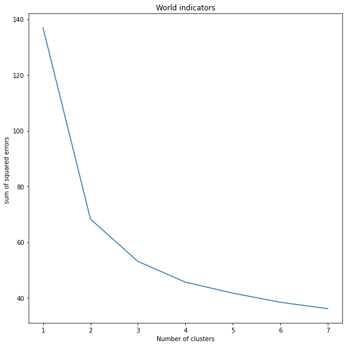

```python
scaler=MinMaxScaler()
data=scaler.fit_transform(df_world.iloc[:,0:16])
world = []
wcss = []
for i in range(1, 8):
  mdl = KMeans(n_clusters=i)
  mdl.fit(data)
  world.append(i)
  wcss.append(mdl.inertia_)
sns.lineplot(world,wcss)
plt.title('World indicators')
plt.xlabel('Number of clusters')
plt.ylabel('sum of squared errors ')
plt.show()
```

Assigning labels to the original data set

```python
k9=KMeans(n_clusters=2)
k9.fit(data)
df_world['KMeans Prediction']=k9.labels_
```

```python
df_world
```

|  | Birth Rate | Business Tax Rate | Days to Start Business | GDP | Health Exp % GDP | Health Exp/Capita | Hours to do Tax | Infant Mortality Rate | Internet Usage | Life Expectancy Female | Life Expectancy Male | Mobile Phone Usage | Population 0-14 | Population 15-64 | Population 65+ | Population Urban | KMeans Prediction |
| --- | --- | --- | --- | --- | --- | --- | --- | --- | --- | --- | --- | --- | --- | --- | --- | --- | --- |
| 0 | 0.025000 | 72.000000 | 25.000000 | 0.012804 | 0.044000 | 233.000000 | 451.000000 | 0.02300 | 0.100000 | 72.000000 | 69.000000 | 0.900000 | 0.272000 | 0.68100 | 0.047000 | 0.682 | 1 |
| 1 | 0.046000 | 52.100000 | 66.000000 | 0.006692 | 0.034000 | 178.000000 | 282.000000 | 0.10700 | 0.100000 | 53.000000 | 50.000000 | 0.500000 | 0.477000 | 0.49900 | 0.024000 | 0.409 | 0 |
| 2 | 0.037000 | 65.900000 | 29.000000 | 0.000459 | 0.045000 | 34.000000 | 270.000000 | 0.06000 | 0.000000 | 60.000000 | 58.000000 | 0.800000 | 0.432000 | 0.53900 | 0.029000 | 0.423 | 0 |
| 3 | 0.024000 | 19.500000 | 60.000000 | 0.000973 | 0.052000 | 404.000000 | 152.000000 | 0.03900 | 0.100000 | 46.000000 | 47.000000 | 1.500000 | 0.340000 | 0.62500 | 0.035000 | 0.565 | 0 |
| 4 | 0.042000 | 43.500000 | 13.000000 | 0.000658 | 0.064000 | 39.000000 | 270.000000 | 0.06800 | 0.000000 | 56.000000 | 55.000000 | 0.500000 | 0.458000 | 0.51700 | 0.025000 | 0.265 | 0 |
| ... | ... | ... | ... | ... | ... | ... | ... | ... | ... | ... | ... | ... | ... | ... | ... | ... | ... |
| 203 | 0.021759 | 44.643094 | 30.331492 | 0.024240 | 0.067362 | 1094.464865 | 279.283333 | 0.02734 | 0.376884 | 72.746193 | 68.035533 | 0.958673 | 0.286963 | 0.63555 | 0.077424 | 0.907 | 1 |
| 204 | 0.013000 | 46.500000 | 5.000000 | 1.000000 | 0.177000 | 8467.000000 | 187.000000 | 0.00600 | 0.700000 | 81.000000 | 76.000000 | 0.900000 | 0.197000 | 0.66900 | 0.133000 | 0.809 | 1 |
| 205 | 0.015000 | 41.900000 | 7.000000 | 0.003030 | 0.088000 | 1213.000000 | 336.000000 | 0.01000 | 0.500000 | 80.000000 | 73.000000 | 1.400000 | 0.223000 | 0.63800 | 0.139000 | 0.946 | 1 |
| 206 | 0.020000 | 62.800000 | 141.000000 | 0.020363 | 0.045000 | 487.000000 | 864.000000 | 0.01400 | 0.400000 | 77.000000 | 71.000000 | 1.000000 | 0.291000 | 0.65100 | 0.058000 | 0.888 | 1 |
| 207 | 0.011000 | 44.643094 | 30.331492 | 0.024240 | 0.067362 | 1094.464865 | 279.283333 | 0.02734 | 0.400000 | 83.000000 | 76.000000 | 0.958673 | 0.206000 | 0.64900 | 0.145000 | 0.948 | 1 |

208 rows × 17 columns

CALINSKI-HARABASZ RATIO ( K MEANS CLUSTERING)

```python
sklearn.metrics.calinski_harabasz_score(data, df_world['KMeans Prediction'] )
```

```
207.22063963084378
```

ValidClust is used to determine the optimal number of clusters

```python
!pip install validclust
```

DUNN INDEX OF WORLD INDICATORS DATASET ( K MEANS CLUSTERING )

```python
from validclust import dunn
from sklearn.metrics import pairwise_distances
```

```python
dunn(pairwise_distances(df_world, metric='euclidean'), k9.labels_)
```

```
0.0016408757869276235
```

SILHOUETTE SCORE ( K MEANS CLUSTERING )

```python
print('KMeans Silhouette Score:',metrics.silhouette_score(data,df_world['KMeans Prediction']))
```

```
KMeans Silhouette Score: 0.41229254606040844
```

Hierarchical Clustering of World Indicators dataset

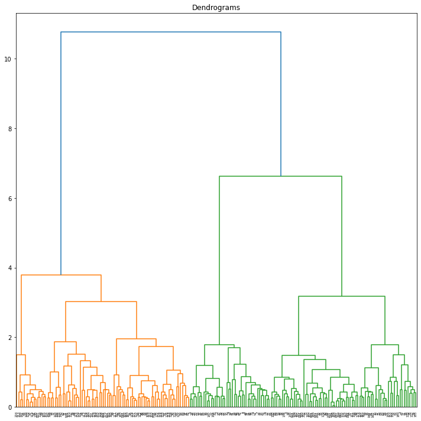

```python
data_scaled = data
import scipy.cluster.hierarchy as shc
plt.figure(figsize=(10, 10))
plt.title("Dendrograms")
dend = shc.dendrogram(shc.linkage(data_scaled,method='ward'))
```

```python
from sklearn.cluster import AgglomerativeClustering
cluster = AgglomerativeClustering(n_clusters=2, linkage='ward')
cluster.fit_predict(data)
df_world['Hierarchical Prediction']=cluster.labels_
```

```python
df_world
```

|  | Birth Rate | Business Tax Rate | Days to Start Business | GDP | Health Exp % GDP | Health Exp/Capita | Hours to do Tax | Infant Mortality Rate | Internet Usage | Life Expectancy Female | Life Expectancy Male | Mobile Phone Usage | Population 0-14 | Population 15-64 | Population 65+ | Population Urban | KMeans Prediction | Hierarchical Prediction |
| --- | --- | --- | --- | --- | --- | --- | --- | --- | --- | --- | --- | --- | --- | --- | --- | --- | --- | --- |
| 0 | 0.025000 | 72.000000 | 25.000000 | 0.012804 | 0.044000 | 233.000000 | 451.000000 | 0.02300 | 0.100000 | 72.000000 | 69.000000 | 0.900000 | 0.272000 | 0.68100 | 0.047000 | 0.682 | 1 | 0 |
| 1 | 0.046000 | 52.100000 | 66.000000 | 0.006692 | 0.034000 | 178.000000 | 282.000000 | 0.10700 | 0.100000 | 53.000000 | 50.000000 | 0.500000 | 0.477000 | 0.49900 | 0.024000 | 0.409 | 0 | 0 |
| 2 | 0.037000 | 65.900000 | 29.000000 | 0.000459 | 0.045000 | 34.000000 | 270.000000 | 0.06000 | 0.000000 | 60.000000 | 58.000000 | 0.800000 | 0.432000 | 0.53900 | 0.029000 | 0.423 | 0 | 0 |
| 3 | 0.024000 | 19.500000 | 60.000000 | 0.000973 | 0.052000 | 404.000000 | 152.000000 | 0.03900 | 0.100000 | 46.000000 | 47.000000 | 1.500000 | 0.340000 | 0.62500 | 0.035000 | 0.565 | 0 | 0 |
| 4 | 0.042000 | 43.500000 | 13.000000 | 0.000658 | 0.064000 | 39.000000 | 270.000000 | 0.06800 | 0.000000 | 56.000000 | 55.000000 | 0.500000 | 0.458000 | 0.51700 | 0.025000 | 0.265 | 0 | 0 |
| ... | ... | ... | ... | ... | ... | ... | ... | ... | ... | ... | ... | ... | ... | ... | ... | ... | ... | ... |
| 203 | 0.021759 | 44.643094 | 30.331492 | 0.024240 | 0.067362 | 1094.464865 | 279.283333 | 0.02734 | 0.376884 | 72.746193 | 68.035533 | 0.958673 | 0.286963 | 0.63555 | 0.077424 | 0.907 | 1 | 0 |
| 204 | 0.013000 | 46.500000 | 5.000000 | 1.000000 | 0.177000 | 8467.000000 | 187.000000 | 0.00600 | 0.700000 | 81.000000 | 76.000000 | 0.900000 | 0.197000 | 0.66900 | 0.133000 | 0.809 | 1 | 1 |
| 205 | 0.015000 | 41.900000 | 7.000000 | 0.003030 | 0.088000 | 1213.000000 | 336.000000 | 0.01000 | 0.500000 | 80.000000 | 73.000000 | 1.400000 | 0.223000 | 0.63800 | 0.139000 | 0.946 | 1 | 1 |
| 206 | 0.020000 | 62.800000 | 141.000000 | 0.020363 | 0.045000 | 487.000000 | 864.000000 | 0.01400 | 0.400000 | 77.000000 | 71.000000 | 1.000000 | 0.291000 | 0.65100 | 0.058000 | 0.888 | 1 | 0 |
| 207 | 0.011000 | 44.643094 | 30.331492 | 0.024240 | 0.067362 | 1094.464865 | 279.283333 | 0.02734 | 0.400000 | 83.000000 | 76.000000 | 0.958673 | 0.206000 | 0.64900 | 0.145000 | 0.948 | 1 | 1 |

208 rows × 18 columns

CALINSKI HARABASZ RATIO (HIERARCHICAL CLUSTERING)

```python
sklearn.metrics.calinski_harabasz_score(data, df_world['Hierarchical Prediction'])
```

```
151.01196139361176
```

DUNN INDEX (HIERARCHICAL CLUSTERING)

```python
dunn(pairwise_distances(df_world, metric='euclidean'), cluster.labels_)
```

```
0.00010412014754670281
```

SILHOUETTE SCORE (HIERARCHICAL CLUSTERING)

```python
print('Hierarchical Silhouette Score:',metrics.silhouette_score(data,df_world['Hierarchical Prediction']))
```

```
Hierarchical Silhouette Score: 0.3249073696157313
```

3 SCATTERPLOTS

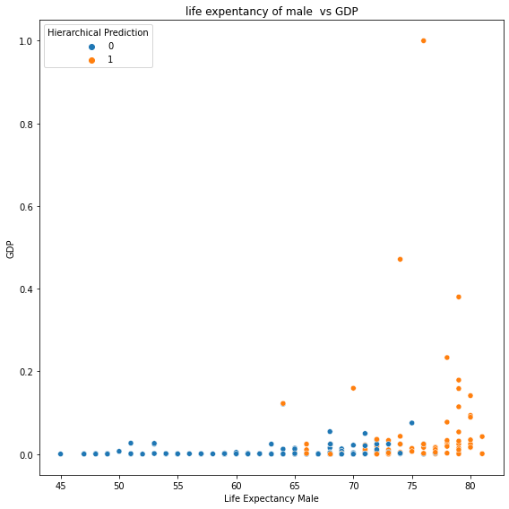

```python
sns.scatterplot(df_world['Life Expectancy Male'],df_world['GDP'],df_world['Hierarchical Prediction'])
plt.title('life expentancy of male  vs GDP')
```

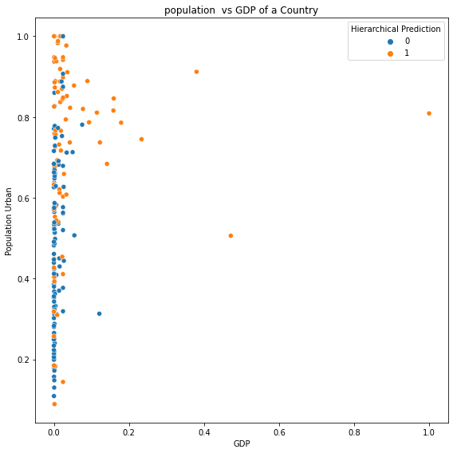

```python
sns.scatterplot(df_world['GDP'],df_world['Population Urban'],df_world['Hierarchical Prediction'])
plt.title('population  vs GDP of a Country')
```

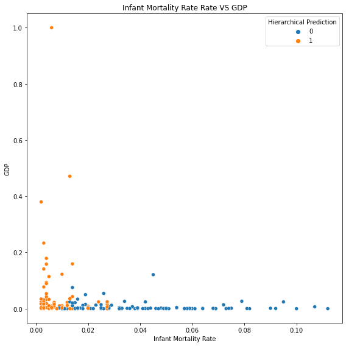

```python
sns.scatterplot(df_world['Infant Mortality Rate'],df_world['GDP'],df_world['Hierarchical Prediction'])
plt.title('Infant Mortality Rate Rate VS GDP')
```

As per our analysis, Calinski Harabasz ratio for K means is higher than hierarchical clustering

Dunn index for k means is higher than hierarchical clustering

silhouette ratio for k means is higher than hierarchical clustering

therefore Kmeans is efficient.